# Analysis of LUAD Data for Prognostic Signatures

Submitted By: **Harpreet Kaur, PhD**

Email: hks04180@gmail.com

**Introduction**

In this analysis, I have used TCGA-LUAD data to identify prognostic signatures. Here, I have used clinical and transcriptomics Data.

# 1. Data Download & Preparation of Data Matrix

## Data Download

Let's downloaded TCGA-LUAD data using the `TCGAbiolinks`

```r
#install.package
if (!requireNamespace("BiocManager", quietly = TRUE))
install.packages("BiocManager")
BiocManager::install("TCGAbiolinks")
```

```r
#Load library
library("TCGAbiolinks")
```

**Data Download**

```r
# Create Query
query_TCGA_LUAD <- GDCquery(project = "TCGA-LUAD", data.category = "Transcriptome Profiling", data.type = "Gene Expression Quantification",  workflow.type = "HTSeq - FPKM", sample.type = c("Primary Tumor", "Solid Tissue Normal"))

# look what type of information there in data

LUAD_res = getResults(query_TCGA_LUAD)

#colnames(LUAD_res)

head(LUAD_res$sample_type )
```

[output not shown]

1. 'Primary Tumor'

2. 'Primary Tumor'

3. 'Primary Tumor'

4. 'Primary Tumor'

5. 'Primary Tumor'

6. 'Primary Tumor'

```r
# download data on your system
GDCdownload(query = query_TCGA_LUAD)
```

```
Downloading data for project TCGA-LUAD

GDCdownload will download 592 files. A total of 308.466673 MB

Downloading as: Tue_Sep_14_20_07_54_2021.tar.gz
```

```
Downloading: 310 MB
```

## Data preparation

After downloading Data from GDC data portal using TCGA biolinks, clinical, metadata were downloaded directly from the portal. Data matrix files were prepared in bash, since R showing memory issues. Major steps for data preparation are as following

1. Create alist of samples directories

```
    cd  /GDCdata/TCGA-LUAD/harmonized/Transcriptome_Profiling/Gene_Expression_Quantification

    ls >samples_list.txt
```

1. bash script written to extract FPKM value from each sample and perform log scale transformation

   log_transform.sh:

   ```
    while read line
    do
    #unzip file
    gzip -d $line/*.gz

    #Extract genes in a file
    awk '{print $1}' $line/*FPKM.txt |perl -pe "s/\n/,/g" |perl -pe "s/,\$/\n/g"  >gene_list.txt

    #Extract FPKM value and take log of the value; Note, 1 was added to handle zero value
    awk '{print log($2+1)}' $line/*FPKM.txt |perl -pe "s/\n/,/g" |perl -pe "s/,\$/\n/g"  >>expression.csv

    #provide list of sample folders
    done <samples_list.txt
   ```

1. Run log_transform.sh script to gene expression matrix and gene list

   ```
    sh  log_transform.sh
   ```

2. add genes IDs to the list

   ```
    cat gene_list.txt expression.csv  >Gene_expression_matrix.txt
   ```

3. metadata.json file converted to csv file. Metadata file contains both TCGA barcode ID and file ID. Since, in our data, we have only ID. Thus, we extracted TCGA barcode IDs corresponding to file ID from the metadata file

   ```
    cut -f3,33,34 metadata.cart.2021-09-12.csv >tcga_file_ids
    cut -d- -f1-3 tcga_file_ids >tcga_3ids
    cut -d- -f1-4 tcga_file_ids >tcga_4ids
    paste tcga_4ids tcga_3ids tcga_file_ids >final_tcga_ids
   ```

1. Clinical information was extarcted from clinical matched with barcode Ids

   ```
    cut -f2,4,10-12,15,16,48,128 clinical.tsv  >clin
    cut -f2,12 exposure.tsv  >smoking_ids
    sort clinical.tsv |uniq >uniq_clin.txt
   ```

2. add sample id to sample_list.txt

   ```
    paste samples_list.txt Gene_expression_matrix.txt >final_gene_expression.txt
   ```

3. Match TCGA IDs with file IDs and keep TCGA barcode IDs as ID column in gene expression file

   ```
    perl row_match.pl  final_gene_expression.txt final_tcga_ids 1 5 |cut -f1-2,8 >final_LUAD_gene_expression.csv
   ```

4. Extract matched clinical data for patients

   ```
    perl row_match.pl final_clinical.txt final_tcga_ids 1 2|cut -f1-2,8- >final_clinical_LUAD.txt
   ```

5. Combine clinical/metadata data with gene expression data to create a complete matrix, where first 14 columns contains clinical data and next 60,483 columns contain gene expression. Here, genes are in the columns and samples are present in rows

   ```
   perl row_match.pl final_LUAD_gene_expression.csv final_clinical_LUAD.txt 1 1 |cut -f1-11,15-  >final_clinical_gene_expression_combined_LUAD.csv

   row_match.pl is script written in perl to match common rows from 2 files
   it can be accessed here: https://github.com/pine-bio-support/ML-Demo/blob/master/row_match.pl
   ```

Note: Few steps (some name substitutions (with bash substitution command) performed within file in bash, those steps might not be mentioned above)

# 2. Load Data

## Load Dataset

Here, we are uploading LUAD gene expression data with clinical data. we already prepared this file in bash after downloading data In the Clinical data, we have information regarding TCGA ids, tumor stage, vital status, vital follow-up/days to death (vital.time), geneder, race, smoking data (cigraettes per day) In the gene expression, we have 60,483 RNA transcripts for 505 patient's samples

```r
#load Data
full_data <- read.table("/content/final_clinical_gene_expression_combined_LUAD.csv", sep=",", header=TRUE, row.names=1, check.names=F)

#Check dimensions of data
dim(full_data)
```

1. 505

2. 60496

```r
#View top rows
head(full_data,5)
```

A data.frame: 5 × 60496

|  | id3 <chr> | tissue_type <chr> | age_at_index <int> | ethnicity <chr> | gender <chr> | race <chr> | vital_status <chr> | vital.time <int> | days_to_death <int> | days_to_last_follow_up <int> | ⋯ | ENSG00000238244.3 <int> | ENSG00000186115.11 <dbl> | ENSG00000216352.1 <dbl> | ENSG00000267117.1 <dbl> | ENSG00000273233.1 <dbl> | ENSG00000105063.17 <dbl> | ENSG00000231119.2 <dbl> | ENSG00000280861.1 <dbl> | ENSG00000123685.7 <dbl> | ENSG00000181518.3 <dbl> |
| --- | --- | --- | --- | --- | --- | --- | --- | --- | --- | --- | --- | --- | --- | --- | --- | --- | --- | --- | --- | --- | --- |
| TCGA-05-4249-01A | TCGA-05-4249 | Cancer | 67 | NA | male | NA | Alive | 1523 | NA | 1523 | ⋯ | 0 | 0.00000000 | 0.0000000 | 0.0668381 | 0 | 2.86530 | 0.2453250 | 0 | 0.664652 | 0 |
| TCGA-05-4250-01A | TCGA-05-4250 | Cancer | 79 | NA | female | NA | Dead | 121 | 121 | NA | ⋯ | 0 | 0.00481688 | 0.0000000 | 0.0665396 | 0 | 2.52848 | 0.3382930 | 0 | 1.084240 | 0 |
| TCGA-05-4382-01A | TCGA-05-4382 | Cancer | 68 | NA | male | NA | Alive | 607 | NA | 607 | ⋯ | 0 | 0.00000000 | 0.0000000 | 0.1392820 | 0 | 2.87089 | 0.0474338 | 0 | 0.975282 | 0 |
| TCGA-05-4384-01A | TCGA-05-4384 | Cancer | 66 | NA | male | NA | Alive | 426 | NA | 426 | ⋯ | 0 | 0.00000000 | 0.0214594 | 0.1815360 | 0 | 2.85965 | 0.4277430 | 0 | 0.731678 | 0 |
| TCGA-05-4389-01A | TCGA-05-4389 | Cancer | 70 | NA | male | NA | Alive | 1369 | NA | 1369 | ⋯ | 0 | 0.03396270 | 0.0000000 | 0.0345575 | 0 | 2.88812 | 0.2819600 | 0 | 1.073680 | 0 |

**Extract clinical Data** Extract clinical Data as clin object This is done, so we can process and gene expression data process dara properly

```r
#Extract clinical Data
clin <- full_data[,1:13]

#check top 5 rows
head(clin,5)
```

A data.frame: 5 × 13

|  | id3 <chr> | tissue_type <chr> | age_at_index <int> | ethnicity <chr> | gender <chr> | race <chr> | vital_status <chr> | vital.time <int> | days_to_death <int> | days_to_last_follow_up <int> | tumor_stage <chr> | cigarettes_per_day <dbl> | tumor_stage.1 <chr> |
| --- | --- | --- | --- | --- | --- | --- | --- | --- | --- | --- | --- | --- | --- |
| TCGA-05-4249-01A | TCGA-05-4249 | Cancer | 67 | NA | male | NA | Alive | 1523 | NA | 1523 | stage ib | 2.849315 | stage ib |
| TCGA-05-4250-01A | TCGA-05-4250 | Cancer | 79 | NA | female | NA | Dead | 121 | 121 | NA | stage iiia | 2.575342 | stage iiia |
| TCGA-05-4382-01A | TCGA-05-4382 | Cancer | 68 | NA | male | NA | Alive | 607 | NA | 607 | stage ib | 3.397260 | stage ib |
| TCGA-05-4384-01A | TCGA-05-4384 | Cancer | 66 | NA | male | NA | Alive | 426 | NA | 426 | stage iiia | 1.095890 | stage iiia |
| TCGA-05-4389-01A | TCGA-05-4389 | Cancer | 70 | NA | male | NA | Alive | 1369 | NA | 1369 | stage ia | 2.356164 | stage ia |

## Extract expression data

Since normalization and analysis can be performed only on numeric values. Thus, we are extarcting gene expression data seprartely from clinical data

```r
#Extract only gene expression Data
exp <- full_data[,14:ncol(full_data)]

#check dimensions and view top rows
dim(exp)
head(exp,5)
```

1. 505

2. 60483

A data.frame: 5 × 60483

|  | ENSG00000242268.2 <dbl> | ENSG00000270112.3 <dbl> | ENSG00000167578.15 <dbl> | ENSG00000273842.1 <dbl> | ENSG00000078237.5 <dbl> | ENSG00000146083.10 <dbl> | ENSG00000225275.4 <dbl> | ENSG00000158486.12 <dbl> | ENSG00000198242.12 <dbl> | ENSG00000259883.1 <dbl> | ⋯ | ENSG00000238244.3 <int> | ENSG00000186115.11 <dbl> | ENSG00000216352.1 <dbl> | ENSG00000267117.1 <dbl> | ENSG00000273233.1 <dbl> | ENSG00000105063.17 <dbl> | ENSG00000231119.2 <dbl> | ENSG00000280861.1 <dbl> | ENSG00000123685.7 <dbl> | ENSG00000181518.3 <dbl> |
| --- | --- | --- | --- | --- | --- | --- | --- | --- | --- | --- | --- | --- | --- | --- | --- | --- | --- | --- | --- | --- | --- |
| TCGA-05-4249-01A | 0.0420376 | 0.0088961 | 1.25412 | 0 | 1.54986 | 2.77539 | 0.0000000 | 0.354064 | 5.06867 | 0.1120870 | ⋯ | 0 | 0.00000000 | 0.0000000 | 0.0668381 | 0 | 2.86530 | 0.2453250 | 0 | 0.664652 | 0 |
| TCGA-05-4250-01A | 0.0211427 | 0.0000000 | 1.24307 | 0 | 1.36885 | 2.61503 | 0.0000000 | 0.150365 | 5.66613 | 0.1290440 | ⋯ | 0 | 0.00481688 | 0.0000000 | 0.0665396 | 0 | 2.52848 | 0.3382930 | 0 | 1.084240 | 0 |
| TCGA-05-4382-01A | 0.0153526 | 0.0000000 | 1.53853 | 0 | 1.88588 | 2.31273 | 0.0382124 | 0.180248 | 5.01561 | 0.0418528 | ⋯ | 0 | 0.00000000 | 0.0000000 | 0.1392820 | 0 | 2.87089 | 0.0474338 | 0 | 0.975282 | 0 |
| TCGA-05-4384-01A | 0.1165740 | 0.0000000 | 1.61805 | 0 | 1.77787 | 3.13405 | 0.0000000 | 0.420188 | 4.80125 | 0.0731625 | ⋯ | 0 | 0.00000000 | 0.0214594 | 0.1815360 | 0 | 2.85965 | 0.4277430 | 0 | 0.731678 | 0 |
| TCGA-05-4389-01A | 0.0000000 | 0.0120485 | 1.56631 | 0 | 1.95414 | 2.43117 | 0.0000000 | 0.353423 | 5.31152 | 0.0394358 | ⋯ | 0 | 0.03396270 | 0.0000000 | 0.0345575 | 0 | 2.88812 | 0.2819600 | 0 | 1.073680 | 0 |

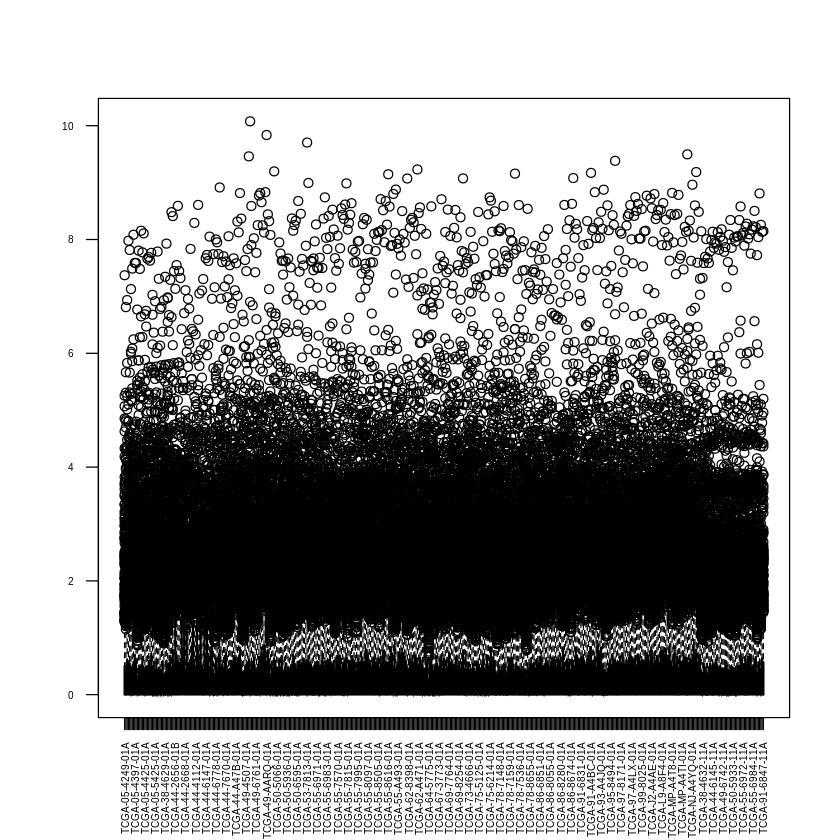

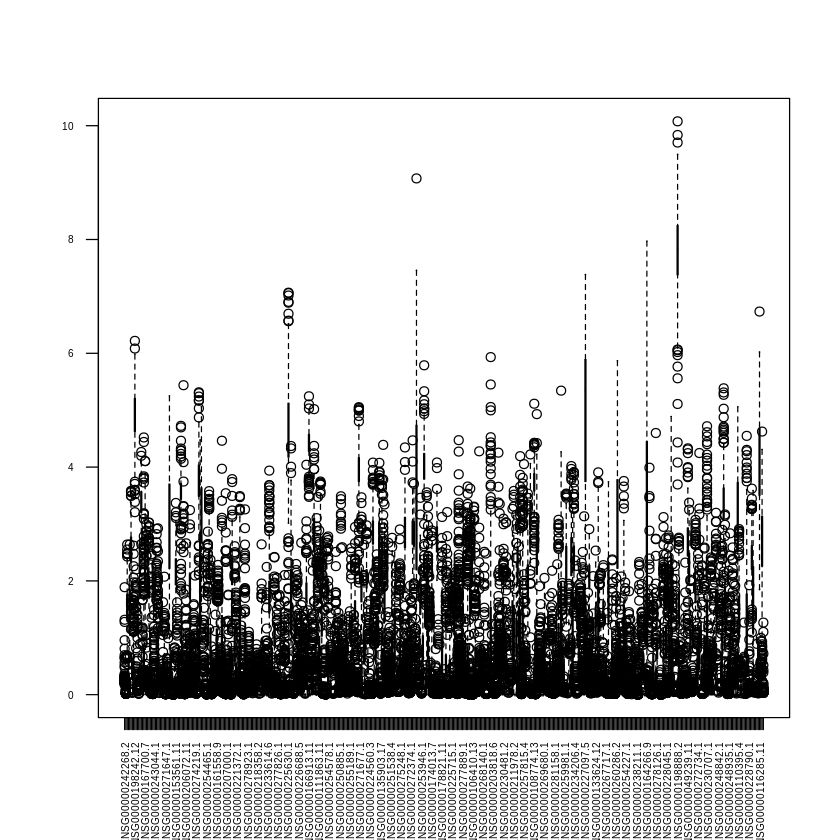

```r
first_500 <- exp[,1:500]

tpose_mat <- t(first_500)
boxplot(tpose_mat, cex.axis=0.5, las=2)

boxplot(first_500, cex.axis=0.5, las=2)
```

# 3. Exploratory Data Analysis

PCA is one of dimensionality reduction method & an exploratory data analysis method, which give us an idea regarding variability & patterns in the data.

Ideally, PCA is performed on normalized data, since, our data is already log scaled (although yet to normalize) transformed. To get an idea, we will perform PCA before and after normalization.

Here, we will perform PCA with `prcomp` functiona and subsequently, draw scatetrplot with PC1 and PC2 using `ggfortify` package

Install packages for PCA plots

```r
install.packages("ggfortify")
```

Load library

```r
library(ggfortify)
```

## Create PCA objects

```r
#PCA object
pca_res <- prcomp(exp)
```

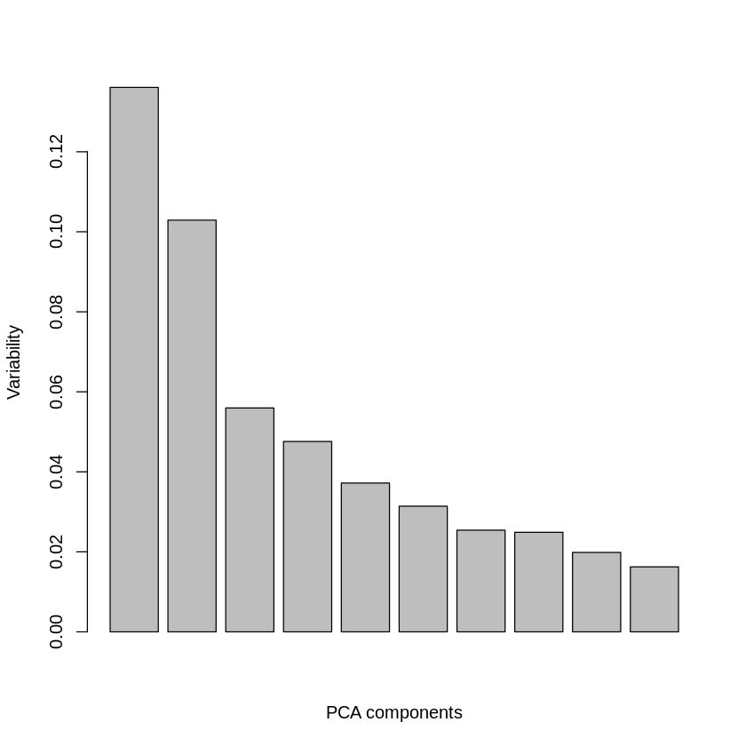

```r
#extract variance explained by PCA componnents
var_explained <- pca_res$sdev^2/sum(pca_res$sdev^2)

#barplot for first 10 components
barplot(var_explained[1:10], xlab="PCA components", ylab="Variability")
```

## Tissue type PCA plot

First, let draw PCA plot based on tissue type, i.e. Cancer & Normal. Here, we will assign color using the `colour= tissue_type`information available in our clinical data/full data

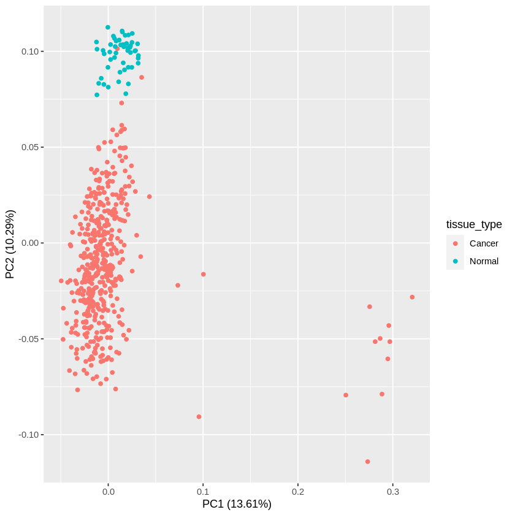

```r
autoplot(pca_res, data=full_data, colour="tissue_type")
```

The PCA plot based on Tissue type indicates the clear distinction between Cancer and Normal samples. Besides, it also showing some of the outliers, we can remove them after their identification. Since, we performed PCA on only log-transformed data, thus we need to check PCA results on normalized data as well. We perform PCA with normalized data as well to make sure we have outliers in the data (We will do it later). Before that, let's explore PCA plot for other clinical characteristics, i.e. gender, stage, vital status etc.

**PCA plot for gender**

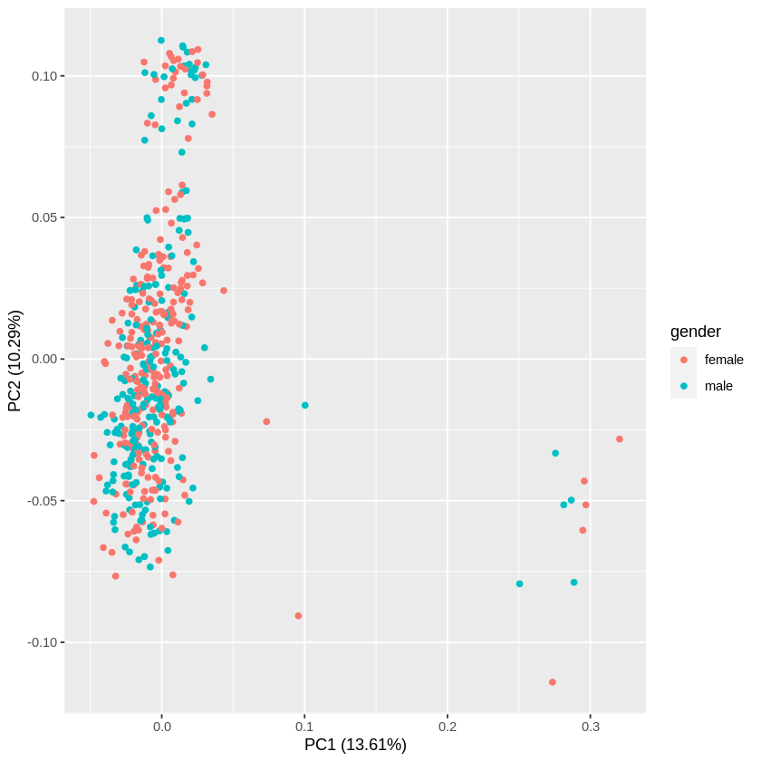

```r
autoplot(pca_res, data=full_data, colour="gender")
```

## PCA plot for tumor stage

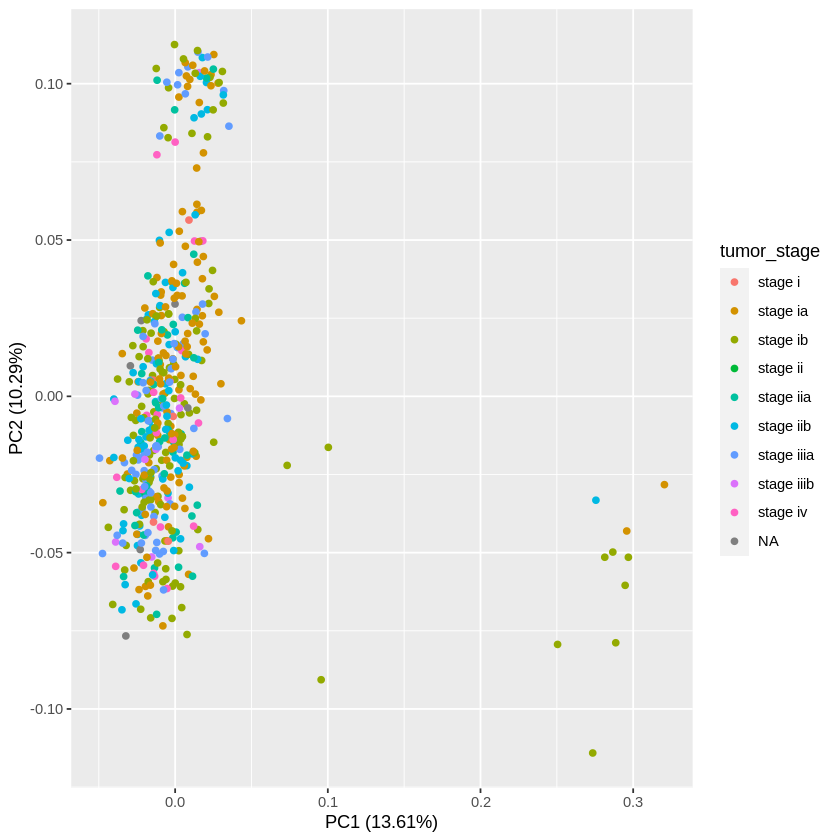

```r
autoplot(pca_res, data=full_data, colour="tumor_stage")
```

## PCA plot for vital status

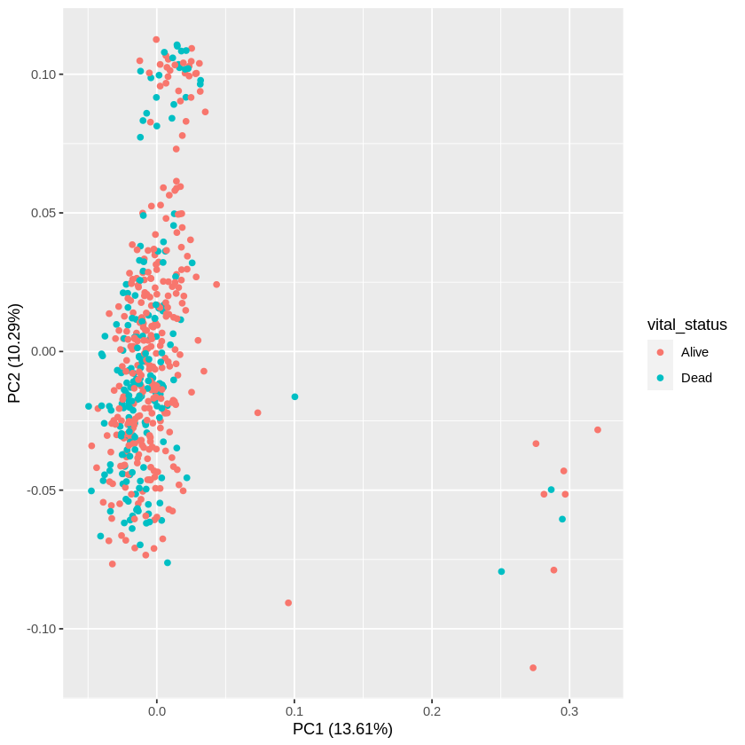

```r
autoplot(pca_res, data=full_data, colour="vital_status")
```

PCA plots have not shown any clear distict pattern for tumor stage, gender, vital status, etc.

This also indicate classifying these conditions based on molecular (transcriptomics) data is itself challenging task. Thus, we need specific molecular signatures that can stratify these groups.

**Data Maniputaion**

Many a times, we need to modify data/column names for analysis. Here, we are going to change some of the names in clinical data for better reprsentaion. e.g. Replacing multiple stages names with single string for stages, e.g. Stage 1A, stage 1B, Stage 1 as Stage_1

For this purpose, we will use `recode` function of the `car` package

```r
#install packages
install.packages("car")
```

```r
#load library
library(car)
```

Change names/value in data. Here, we will create extra columns with new names keeping original names in data

```r
clin$OS <- recode(clin$vital_status,"c('Dead')=1;c('Alive')=0")

clin$stage <- recode(clin$tumor_stage,"c('stage ia','stage ib','stage i')='Stage_1';c('stage iia','stage iib','stage ii')='Stage_2';c('stage iiia','stage iiib','stage iii')='Stage_3'; c('stage iv')='Stage_4'")

clin$stage_n <- recode(clin$tumor_stage,"c('stage ia','stage ib','stage i')=1;c('stage iia','stage iib','stage ii')=2; c('stage iiia','stage iiib','stage iii')=3; c('stage iv')= 4")
```

Combine clinical data (conatining new columns) with expression data. Here, we are combining both data column-wise using `cbind`

```r
Full_data1 <- cbind(clin, exp)
```

To make sure, new column added in clinical data; let's draw PCA plot with new column `stage`

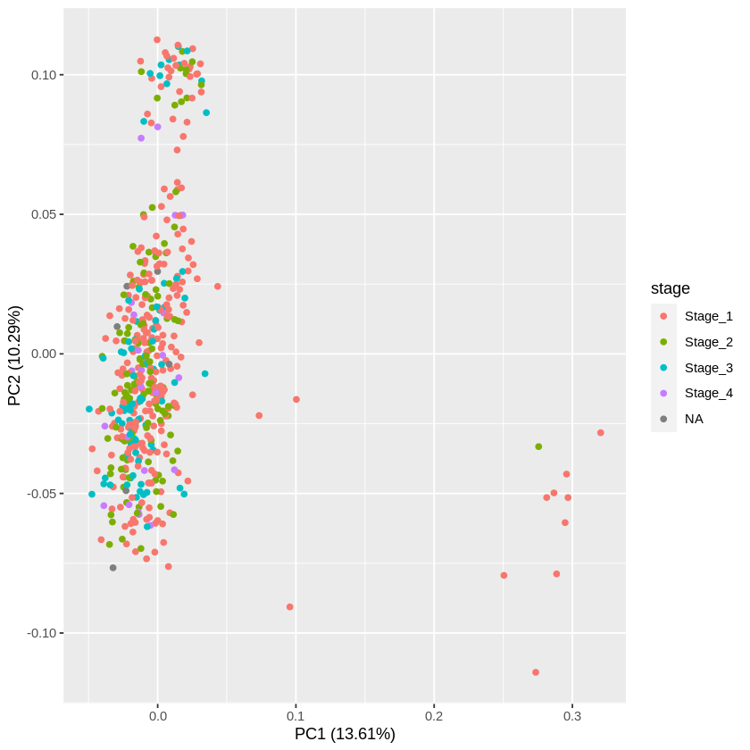

```r
autoplot(pca_res, data=Full_data1, colour="stage")
```

# 4. Training & Test data preparation & Normalization for Analysis

We can apply machine learning and statiscal analytical methods primarily on normalized data. But, before normalization, we must prepare our data properly. Here, we will prepare our training and test data.

**Training data** will be used for used feature selection/feature reduction and to train the models.

**Test data** will be used assess the performance of prediction model devevloped based on identified molecular signatures.

Since, in this analysis, our goal is to identify prognostic signature/predictor for LUAD cancer.

From the previous literature it is known that tumor stage is the key factor which plays a vital role in the prognosis of patients. Thus, first, we will prepare training and test dataset based on tumor stage.

80% data from each stage will be included in training data and 20% data will be included in test data.

Besides, exploratory data analysis using PCA (see PCA plot based on stage) shows that there are some samples where we have no information (NA)regarding tumor stage. Thus, we considering only stage_1, stage_2 , stage_3 and stage_4 samples.

## Extract data for each stage

```r
# Extract data for each stage
stage1 = subset(Full_data1, stage == "Stage_1")
stage2 = subset(Full_data1, stage == "Stage_2")
stage3 = subset(Full_data1, stage == "Stage_3")
stage4 = subset(Full_data1, stage == "Stage_4")

#Check dimensions of extracted data
dim(stage1)
dim(stage2)
dim(stage3)
dim(stage4)
```

1. 267

2. 60499

1. 122

2. 60499

1. 85

2. 60499

1. 24

2. 60499

## Prepare training (80%) and test (20%) data for each stage independently

```r
set.seed(7)
#Split training and test data into 80:20 ratio
dt1 = sort(sample(nrow(stage1), nrow(stage1)*.8))

#Training Data
train_s1<-stage1[dt1,]

#Test Dataset
test_s1<-stage1[-dt1,]

#Split training and test data into 80:20 ratio
dt2 = sort(sample(nrow(stage2), nrow(stage2)*.8))

#Training Data
train_s2<-stage2[dt2,]

#Test Dataset
test_s2<-stage2[-dt2,]


#Split training and test data into 80:20 ratio
dt3 = sort(sample(nrow(stage3), nrow(stage3)*.8))

#Training Data
train_s3<-stage3[dt3,]

#Test Dataset
test_s3<-stage3[-dt3,]


#Split training and test data into 80:20 ratio
dt4 = sort(sample(nrow(stage4), nrow(stage4)*.8))

#Training Data
train_s4<-stage4[dt4,]

#Test Dataset
test_s4<-stage4[-dt4,]


# final train and test

train_set <- rbind(train_s1, train_s2, train_s3, train_s4)

test_set <- rbind(test_s1, test_s2, test_s3, test_s4)


#Write into files
write.table(train_set, file = "train_set.txt", sep="\t", quote=F, row.names = F)

write.table(test_set, file = "test_set.txt", sep="\t", quote=F, row.names = F)
```

**Extract clinical data for training and test**

```r
#Extract clinical data for training and test
train_clin <- train_set[,1:16]
test_clin <- test_set[,1:16]

#View top rows
head(train_clin[1:16],5)
```

A data.frame: 5 × 16

|  | id3 <chr> | tissue_type <chr> | age_at_index <int> | ethnicity <chr> | gender <chr> | race <chr> | vital_status <chr> | vital.time <int> | days_to_death <int> | days_to_last_follow_up <int> | tumor_stage <chr> | cigarettes_per_day <dbl> | tumor_stage.1 <chr> | OS <dbl> | stage <chr> | stage_n <dbl> |
| --- | --- | --- | --- | --- | --- | --- | --- | --- | --- | --- | --- | --- | --- | --- | --- | --- |
| TCGA-05-4249-01A | TCGA-05-4249 | Cancer | 67 | NA | male | NA | Alive | 1523 | NA | 1523 | stage ib | 2.8493151 | stage ib | 0 | Stage_1 | 1 |
| TCGA-05-4382-01A | TCGA-05-4382 | Cancer | 68 | NA | male | NA | Alive | 607 | NA | 607 | stage ib | 3.3972603 | stage ib | 0 | Stage_1 | 1 |
| TCGA-05-4389-01A | TCGA-05-4389 | Cancer | 70 | NA | male | NA | Alive | 1369 | NA | 1369 | stage ia | 2.3561644 | stage ia | 0 | Stage_1 | 1 |
| TCGA-05-4390-01A | TCGA-05-4390 | Cancer | 58 | NA | female | NA | Alive | 1126 | NA | 1126 | stage ib | 0.8219178 | stage ib | 0 | Stage_1 | 1 |
| TCGA-05-4420-01A | TCGA-05-4420 | Cancer | 41 | NA | male | NA | Alive | 912 | NA | 912 | stage ib | 2.0821918 | stage ib | 0 | Stage_1 | 1 |

Extract only expression data for training and test data (which is required for normalization

```r
#extract only expression values
train_exp <- train_set[17:ncol(train_set)]
test_exp <- test_set[17:ncol(test_set)]

#Check dimensions
dim(train_exp)
dim(test_exp)
```

1. 397

2. 60483

1. 101

2. 60483

## Data Pre-processing & Normalization

It is important to remove those features (genes) from data that contribute only noise Thus, we will remove those genes having zero value and equal variance in 80% of samples using `NZV` method from `caret` package and `predict` function used for predicting values for training and test data

Next, we will normalize our training and test data with center and scale methods. Eventually, we will obtain zscore normalized data

```r
#install caret package
install.packages("caret")
```

```r
#load library
library("caret")
```

```r
# remove near zero variation for the columns at least or 80% of the values are the same
# this function creates the filter
nzv <- preProcess(train_exp,method="nzv",uniqueCut = 20)

# apply the above created filter using "predict" function
nzv_exp_tr <- predict(nzv,train_exp)
nzv_exp_te <- predict(nzv,test_exp)

# center & scaling
processCenter <- preProcess(nzv_exp_tr, method = c("center", "scale"))

# apply center & scaling on traning and test data
Norm_tr_exp <- predict(processCenter,nzv_exp_tr)
Norm_te_exp <- predict(processCenter,nzv_exp_te)

#round up value upto 3 digits
Norm_tr_exp <- round(Norm_tr_exp,3)
Norm_te_exp <- round(Norm_te_exp,3)
```

```r
#check dimension of normalized data
dim(Norm_tr_exp)
dim(Norm_te_exp)
```

1. 397

2. 39482

1. 101

2. 39482

```r
train_set1 <- cbind(train_clin, Norm_tr_exp )
test_set1 <- cbind(test_clin, Norm_te_exp )
```

## Visualization of normalized data

```r
head(Norm_tr_exp[1:10],5)
```

A data.frame: 5 × 10

|  | ENSG00000242268.2 <dbl> | ENSG00000270112.3 <dbl> | ENSG00000167578.15 <dbl> | ENSG00000078237.5 <dbl> | ENSG00000146083.10 <dbl> | ENSG00000158486.12 <dbl> | ENSG00000198242.12 <dbl> | ENSG00000259883.1 <dbl> | ENSG00000231981.3 <dbl> | ENSG00000134108.11 <dbl> |
| --- | --- | --- | --- | --- | --- | --- | --- | --- | --- | --- |
| TCGA-05-4249-01A | -0.157 | -0.021 | -0.903 | -0.293 | 0.623 | -0.039 | 0.346 | -0.068 | -0.121 | -0.619 |
| TCGA-05-4382-01A | -0.362 | -0.222 | -0.071 | 0.774 | -0.714 | -0.490 | 0.219 | -0.353 | -0.157 | 0.238 |
| TCGA-05-4389-01A | -0.481 | 0.051 | 0.010 | 0.991 | -0.372 | -0.041 | 0.927 | -0.362 | -0.250 | -0.527 |
| TCGA-05-4390-01A | -0.481 | -0.089 | -1.316 | 0.382 | -0.234 | -0.631 | 0.616 | -0.367 | -0.250 | 0.082 |
| TCGA-05-4420-01A | -0.481 | -0.172 | -1.475 | 1.784 | -0.810 | 0.085 | 0.742 | -0.234 | -0.250 | 0.072 |

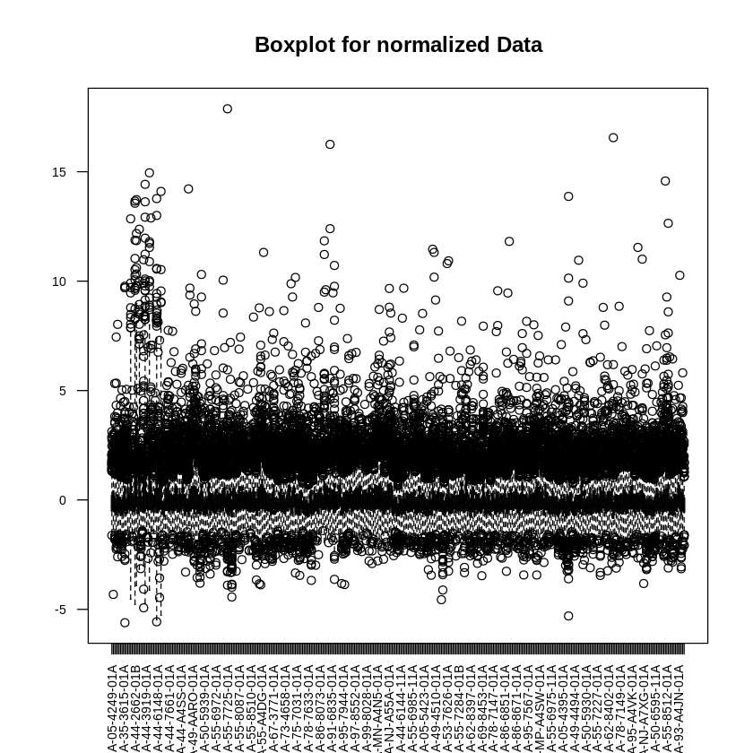

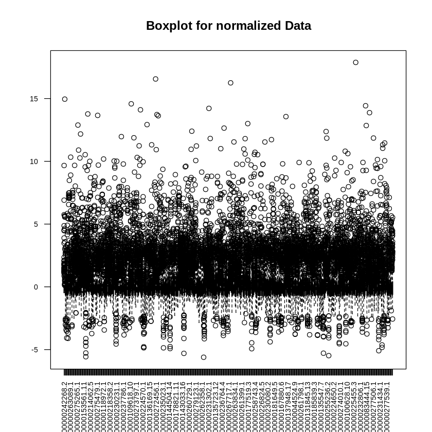

```r
### Visulization
Norm_exp_t <- t(Norm_tr_exp[1:500])

boxplot(Norm_exp_t, las=2, cex.axis=0.7, main="Boxplot for normalized Data")

boxplot(Norm_tr_exp[1:500], las=2, cex.axis=0.7, main="Boxplot for normalized Data")
```

# 5. Exploratory Data analysis after Data Normalization**

## Create PCA object for normalized Data

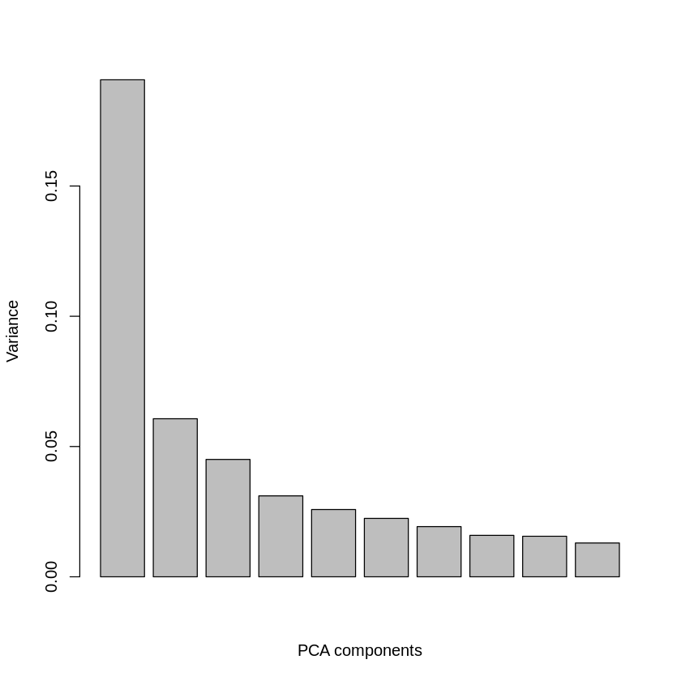

```r
#PCA for pre-processed data
pca_res1 <- prcomp(Norm_tr_exp)

#variance explained by PCA components
var_explained1 <- pca_res1$sdev^2/sum(pca_res1$sdev^2)

#barplot for first 10 components
barplot(var_explained1[1:10], xlab="PCA components", ylab="Variance")
```

## PCA plot for tissue type

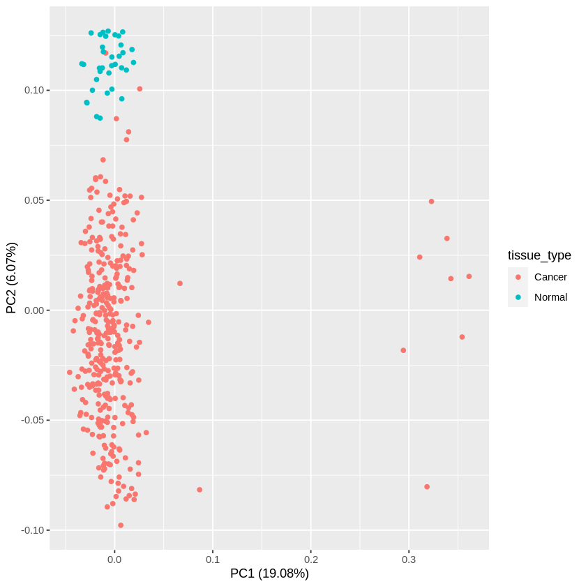

```r
autoplot(pca_res1, data=train_set, colour="tissue_type")
```

PCA plot based on normalized data showing the better separation and PC1 and PC2 reprsents more variability, i.e., ~25%. But, still it showing outliers (on the right side). Next, let's identify these outliers

## Outliers Identification

To identify outleir samples, we can label samples using `label=TRUE`

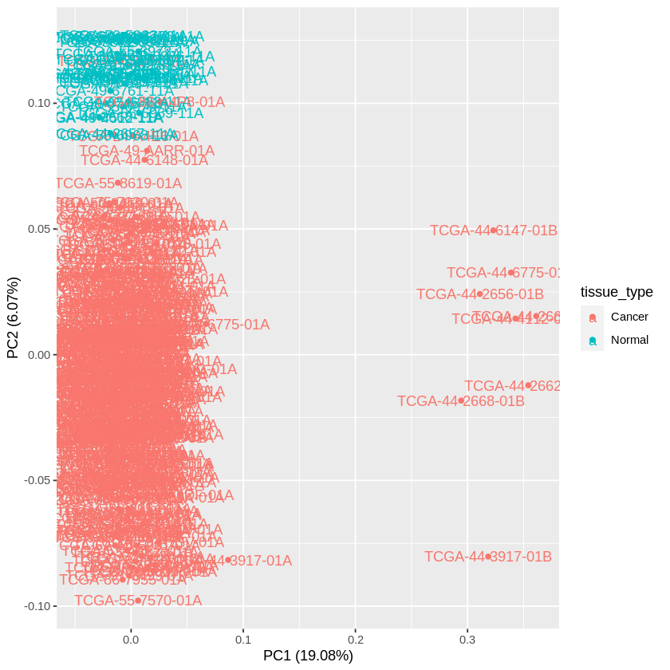

```r
autoplot(pca_res1, data=train_set, colour="tissue_type", label=TRUE)
```

On assessing these outliers, it has been observed that these samples ID names ends with -01B or -01C; which represent different vials for samples from the same site.

This also indicate, handling of data extraction or sample extraction can impact the analysis

## Outliers Removal

**Find the index (row number) for outliers**

To Remove the outliers , next, we will identify the index (row number) with sample ID using `which` function

```r
#get row index
which(rownames(train_set1) %in% c("TCGA-44-3917-01B", "TCGA-44-2668-01B", "TCGA-44-2662-01B","TCGA-44-2656-01B", "TCGA-44-6146-01B", "TCGA-44-6147-01B","TCGA-44-6775-01C", "TCGA-55-7284-01B", "TCGA-44-4112-01B","TCGA-44-2666-01B" , "TCGA-55-7913-01B" ))
```

1. 14

2. 17

3. 18

4. 20

5. 24

6. 27

7. 32

8. 35

9. 87

10. 241

**Outliers Removal**

Here, we will remove outlier samples using index values

```r
# drop row with row index
train_set2 <- train_set1[-c(14, 17, 18, 20, 24, 27, 32,35, 87, 241),]
dim(train_set1)
dim(train_set2)
```

1. 397

2. 39498

1. 387

2. 39498

**PCA after outlier removal**

```r
data_pca <- train_set2[17:ncol(train_set2)]
```

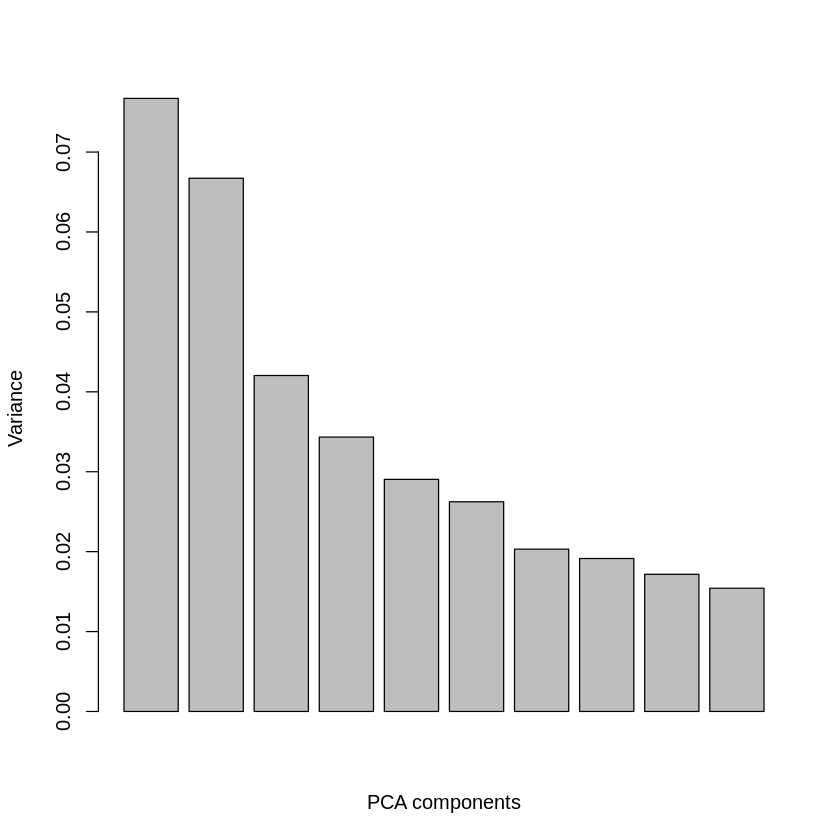

```r
#PCA for pre-processed data
pca_res2 <- prcomp(data_pca)

#variance explained by PCA components
var_explained2 <- pca_res2$sdev^2/sum(pca_res2$sdev^2)

#barplot for first 10 components
barplot(var_explained2[1:10], xlab="PCA components", ylab="Variance")
```

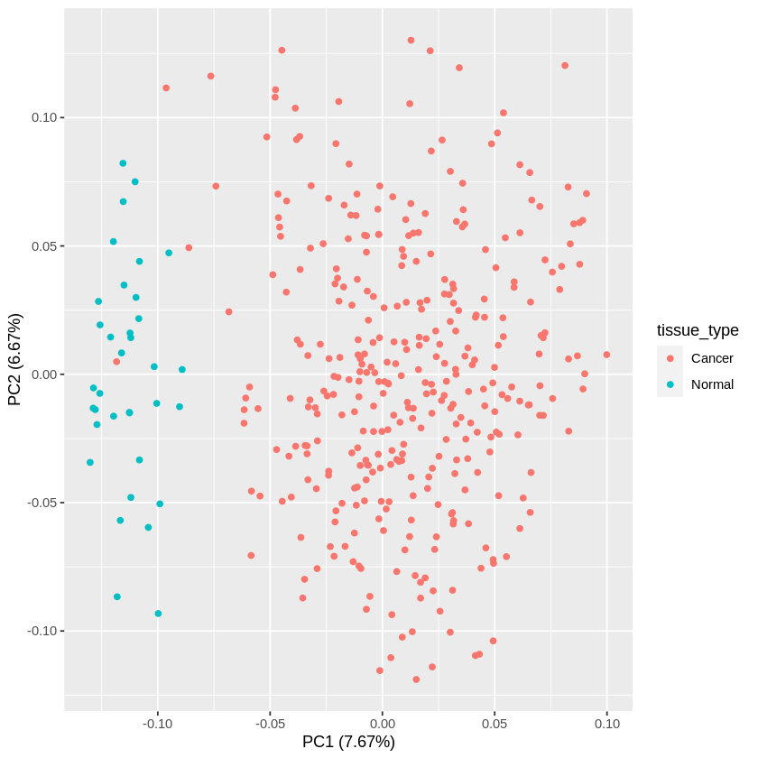

```r
autoplot(pca_res2, data=train_set2, colour="tissue_type")
```

After outliers removal, we can clearly see the distict pattern in cancer and normal samples Now, our training data is ready for downstream analysis.

```r
dim(train_set2)
```

1. 387

2. 39498

# 6. Feature selection/reduction

In our training data, we still have more than 39K features or RNA transcripts. To develop a good prediction model, we must must have only important features, other will results only in noise. Besides, ML prediction models based on large number of features usually computationally very expensive.

Thus, it is important to consider only relevant features in ML based biomedical data analysis. There are number of approaches that can be used to identify relevant features.

Let's first apply simplest approach, i.e. significantly differentially expressed genes between cancer and normal or non-tumorous samples. Since, we are looking for prognostic signatures for LUAD patients, thus genes that similarly expressed between cancer and normal definitly not relevant.

## Differential Gene Expression Analysis

There are number of methods, i.e. Wilcoxon T-test, DESeq2, EdgeR, Limma that can be used to identify differentially expressed genes. Choice of method would be based on type of values in the data. For instance, DESeq2 and EdgeR can be applied on non-normalized data Raw read count data, Limma can used for microarray data. Wilcoxon and Welch tests can applied on normalized data.Since, our data is already Zscore- normalized , thus we can apply directly wilcoxon ranking test.

**Prepare data for Wilcoxon ranking T-test**

Since, we want to identify significantly differentially expressed genes between cancer and normal samples. Now, let's extract data for cancer and normal samples. We added Cancer and normal information based on TCGA barcode ID.

```r
#Prepare groups
group1 = subset(train_set2, tissue_type== "Cancer")
group2 = subset(train_set2, tissue_type== "Normal")

dim(group1)
dim(group2)
```

1. 352

2. 39498

1. 35

2. 39498

```r
head(group1[17:20],5)
```

A data.frame: 5 × 4

|  | ENSG00000242268.2 <dbl> | ENSG00000270112.3 <dbl> | ENSG00000167578.15 <dbl> | ENSG00000078237.5 <dbl> |
| --- | --- | --- | --- | --- |
| TCGA-05-4249-01A | -0.157 | -0.021 | -0.903 | -0.293 |
| TCGA-05-4382-01A | -0.362 | -0.222 | -0.071 | 0.774 |
| TCGA-05-4389-01A | -0.481 | 0.051 | 0.010 | 0.991 |
| TCGA-05-4390-01A | -0.481 | -0.089 | -1.316 | 0.382 |
| TCGA-05-4420-01A | -0.481 | -0.172 | -1.475 | 1.784 |

```r
#combine cancer & Normal
C_N_data <- rbind(group1[17:ncol(group1)], group2[17:ncol(group2)])

#prepare t_test input
t_test_input <- t(C_N_data)

dim(t_test_input)

#view first 5 rows of the data
head(t_test_input,5)

#Extract feature names
genes <- row.names(t_test_input)
```

1. 39482

2. 387

A matrix: 5 × 387 of type dbl

|  | TCGA-05-4249-01A | TCGA-05-4382-01A | TCGA-05-4389-01A | TCGA-05-4390-01A | TCGA-05-4420-01A | TCGA-05-4426-01A | TCGA-05-4433-01A | TCGA-05-5715-01A | TCGA-35-3615-01A | TCGA-38-4630-01A | ⋯ | TCGA-44-3396-11A | TCGA-49-4512-11A | TCGA-49-6743-11A | TCGA-49-6745-11A | TCGA-49-6761-11A | TCGA-50-5933-11A | TCGA-50-5936-11A | TCGA-50-6595-11A | TCGA-55-6981-11A | TCGA-55-6968-11A |
| --- | --- | --- | --- | --- | --- | --- | --- | --- | --- | --- | --- | --- | --- | --- | --- | --- | --- | --- | --- | --- | --- |
| ENSG00000242268.2 | -0.157 | -0.362 | -0.481 | -0.481 | -0.481 | -0.481 | -0.149 | -0.481 | -0.481 | -0.036 | ⋯ | 0.297 | -0.481 | 0.112 | -0.199 | -0.481 | -0.235 | 0.106 | 0.181 | 1.831 | -0.130 |
| ENSG00000270112.3 | -0.021 | -0.222 | 0.051 | -0.089 | -0.172 | -0.122 | -0.222 | -0.073 | -0.222 | 0.736 | ⋯ | -0.166 | -0.085 | -0.222 | -0.222 | -0.222 | -0.222 | -0.222 | -0.222 | 0.141 | -0.076 |
| ENSG00000167578.15 | -0.903 | -0.071 | 0.010 | -1.316 | -1.475 | -1.879 | -0.036 | -0.988 | 0.130 | -0.305 | ⋯ | -0.177 | 0.162 | -0.410 | 0.513 | 0.527 | -0.282 | -0.311 | -0.044 | 0.626 | 1.005 |
| ENSG00000078237.5 | -0.293 | 0.774 | 0.991 | 0.382 | 1.784 | -0.556 | 0.006 | 0.372 | 0.663 | -0.875 | ⋯ | 0.279 | -0.127 | 0.212 | -0.119 | 0.143 | -0.114 | -0.202 | -0.562 | -0.158 | 0.389 |
| ENSG00000146083.10 | 0.623 | -0.714 | -0.372 | -0.234 | -0.810 | 2.922 | 0.658 | -1.522 | 0.829 | 2.379 | ⋯ | -0.373 | -3.183 | -1.268 | -2.271 | -0.251 | -1.074 | -0.328 | -0.070 | 0.045 | -0.549 |

```r
dim(t_test_input)
```

1. 39482

2. 387

## Wilcoxon Test

Apply Wilcoxon test on data between cancer & Normal samples

```r
Wilcoxon <- apply(t_test_input[,1:ncol(t_test_input)], 1, function (x) wilcox.test(x[1:352],x[353:387],paired=F))
```

Extract p-values, FDR, Fold change(FC), Bonferroni adjusted p-value from the results

```r
#Extract P-values
p_value_w <- unlist(lapply(Wilcoxon, function(x) x$p.value))

#Extract FDR
fdr_w <- p.adjust(p_value_w, method = "fdr")

#Extract Boneferroni adjusted P-values
boneferroni_w <- p.adjust(p_value_w, method = "bonferroni")

#Make list
list_w <- Map(c, p_value_w, fdr_w, boneferroni_w)

#make dataframe of the list
result_w<- data.frame(matrix(unlist(list_w), nrow=length(list_w), byrow=T))

#calculate the mean of each gene per cancer group group
cancer = apply(t_test_input[,1:352], 1, mean)

#calcuate the mean of each gene per normal group
normal = apply(t_test_input[, 353:387], 1, mean)

foldchange <- as.data.frame(cancer/normal)

#Combine with the gene
result_w1 <-cbind(genes,result_w,foldchange )

#Provide the column names to both groups
colnames(result_w1) <- c("Gene_ID","P_value","FDR","Boneferroni", "FC")
```

## Identification significantly DEGs

**Identification significantly differentially expressed genes**

first Sort results based on FDR value using `order`function. Here, I am using FDR < 0.05 to identify significant genes.

Further, applying Fold change criteria FC >= +1.2 and FC< = -1.2 for identification of upregulated genes and downregulated genes, respectively.

```r
# Sort features based on FDRy value
sorted_features <- as.data.frame(result_w1[order(result_w1[,"FDR"], decreasing =  FALSE),])

#select significant features based on FDR <0.05
sig_features <- sorted_features[sorted_features$FDR < 0.05, ]

#select top features based on FDR <0.05 & FC > +/- 1.2
# upregulated genes
upreg_features <- sig_features[sig_features$FC > 1.2, ]

#upregulated genes
downreg_features <- sig_features[sig_features$FC < -1.2, ]

#Check dimensions
dim(upreg_features)
dim(downreg_features)

#Create top feature combining both significantly upregulated and downregulated genes
top_features <- rbind(upreg_features,downreg_features)
dim(top_features)

#Write results into a file
write.table(top_features,file="significant_gene_result.txt", sep='\t',  quote = F,row.names = FALSE)

#view top rows for results
head(top_features)
```

1. 263

2. 5

1. 331

2. 5

1. 594

2. 5

A data.frame: 6 × 5

|  | Gene_ID <chr> | P_value <dbl> | FDR <dbl> | Boneferroni <dbl> | FC <dbl> |
| --- | --- | --- | --- | --- | --- |
| ENSG00000250280.2 | ENSG00000250280.2 | 1.047854e-11 | 8.902812e-11 | 4.137137e-07 | 251.988636 |
| ENSG00000181541.5 | ENSG00000181541.5 | 5.349235e-10 | 3.488578e-09 | 2.111985e-05 | 3.891182 |
| ENSG00000251011.4 | ENSG00000251011.4 | 9.916718e-10 | 6.227642e-09 | 3.915319e-05 | 7.346728 |
| ENSG00000235731.1 | ENSG00000235731.1 | 1.195481e-09 | 7.421380e-09 | 4.719997e-05 | 4.649381 |
| ENSG00000169836.4 | ENSG00000169836.4 | 1.280548e-09 | 7.909669e-09 | 5.055861e-05 | 2.397145 |
| ENSG00000259379.1 | ENSG00000259379.1 | 6.498357e-09 | 3.606018e-08 | 2.565682e-04 | 5.046939 |

From the Differentially Gene expression analysis, we are left with few hundered important features from 39K. Now, we can use these features for downstream analysis

Draw Volcano plot to visualize significant gene pattern

```r
install.packages("ggplot2")
```

```r
library(ggplot2)
```

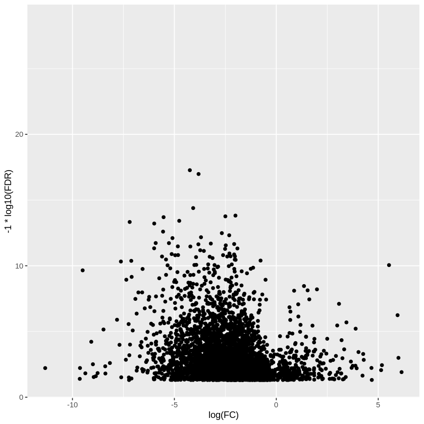

```r
#draw volcano plot
volcano = ggplot(data = sig_features, aes(x = log(FC), y = -1*log10(FDR)))
volcano + geom_point()
```

## Create Training and test data with selected features (significant genes) only

```r
#Prepare dataset (training/test) for selected only
top1 <- as.data.frame(top_features$Gene_ID)
colnames(top1) <- c("ID")
#head(top1)

#Transpose training and test data to extract genes
train_set2_t <- t(train_set2)
test_set1_t <- t(test_set1)

# Prepare training data with only selected top features
tr_selected_data <- as.data.frame(train_set2_t[row.names(train_set2_t) %in% c(top1$ID), ])


# Prepare test data with only selected top features
te_selected_data <- as.data.frame(test_set1_t[row.names(test_set1_t) %in% c(top1$ID), ])

#Check dimensions of dataset
dim(tr_selected_data)
dim(te_selected_data)
```

1. 594

2. 387

1. 594

2. 101

```r
head(tr_selected_data,5)
head(te_selected_data,5)
```

A data.frame: 5 × 387

|  | TCGA-05-4249-01A <chr> | TCGA-05-4382-01A <chr> | TCGA-05-4389-01A <chr> | TCGA-05-4390-01A <chr> | TCGA-05-4420-01A <chr> | TCGA-05-4426-01A <chr> | TCGA-05-4433-01A <chr> | TCGA-05-5715-01A <chr> | TCGA-35-3615-01A <chr> | TCGA-38-4630-01A <chr> | ⋯ | TCGA-73-4666-01A <chr> | TCGA-73-4670-01A <chr> | TCGA-78-7145-01A <chr> | TCGA-78-7160-01A <chr> | TCGA-78-7167-01A <chr> | TCGA-93-A4JN-01A <chr> | TCGA-93-A4JP-01A <chr> | TCGA-97-8171-01A <chr> | TCGA-99-8033-01A <chr> | TCGA-55-6968-11A <chr> |
| --- | --- | --- | --- | --- | --- | --- | --- | --- | --- | --- | --- | --- | --- | --- | --- | --- | --- | --- | --- | --- | --- |
| ENSG00000259883.1 | -0.068 | -0.353 | -0.362 | -0.367 | -0.234 | -0.290 | 0.491 | -0.348 | -0.457 | -0.254 | ⋯ | -0.459 | 0.143 | -0.159 | -0.382 | -0.144 | -0.309 | 0.028 | -0.522 | -0.057 | -0.522 |
| ENSG00000231981.3 | -0.121 | -0.157 | -0.250 | -0.250 | -0.250 | -0.250 | -0.250 | -0.250 | -0.144 | -0.250 | ⋯ | -0.250 | -0.250 | -0.250 | -0.250 | -0.144 | -0.250 | 0.060 | -0.250 | -0.250 | 0.025 |
| ENSG00000263089.1 | -0.085 | -0.468 | -0.491 | -0.472 | -0.320 | -0.334 | 1.369 | -0.423 | -0.283 | -0.429 | ⋯ | -0.322 | -0.456 | -0.417 | -0.476 | 0.220 | 0.013 | -0.084 | -0.106 | -0.118 | -0.051 |
| ENSG00000233540.1 | 1.450 | 0.129 | -0.040 | -0.455 | -0.455 | -0.455 | -0.455 | 0.431 | -0.455 | 0.376 | ⋯ | -0.128 | -0.455 | 1.357 | -0.455 | -0.117 | -0.455 | -0.455 | -0.455 | -0.095 | -0.455 |
| ENSG00000273797.1 | -0.353 | -0.192 | -0.288 | -0.417 | -0.369 | -0.056 | -0.287 | -0.276 | -0.161 | -0.120 | ⋯ | -0.315 | -0.159 | -0.219 | -0.195 | 0.068 | 0.338 | -0.116 | -0.131 | -0.198 | -0.149 |

A data.frame: 5 × 101

|  | TCGA-05-4417-01A <chr> | TCGA-05-4422-01A <chr> | TCGA-35-4122-01A <chr> | TCGA-38-4625-01A <chr> | TCGA-38-4631-01A <chr> | TCGA-44-2657-01A <chr> | TCGA-44-2666-01A <chr> | TCGA-44-5645-01B <chr> | TCGA-44-7671-01A <chr> | TCGA-44-7672-01A <chr> | ⋯ | TCGA-97-8547-01A <chr> | TCGA-99-8025-01A <chr> | TCGA-MP-A4T6-01A <chr> | TCGA-MP-A4T9-01A <chr> | TCGA-50-5930-11A <chr> | TCGA-78-7156-01A <chr> | TCGA-86-7701-01A <chr> | TCGA-L9-A5IP-01A <chr> | TCGA-MP-A4T7-01A <chr> | TCGA-38-4632-11A <chr> |
| --- | --- | --- | --- | --- | --- | --- | --- | --- | --- | --- | --- | --- | --- | --- | --- | --- | --- | --- | --- | --- | --- |
| ENSG00000259883.1 | -0.089 | -0.267 | -0.244 | -0.211 | -0.522 | 0.063 | 2.793 | 8.409 | -0.382 | -0.343 | ⋯ | 0.116 | 0.002 | 0.087 | 0.494 | -0.366 | -0.388 | -0.034 | 0.290 | 0.134 | -0.180 |
| ENSG00000231981.3 | -0.008 | -0.250 | -0.250 | -0.250 | -0.250 | -0.250 | 3.460 | 7.998 | -0.250 | -0.250 | ⋯ | -0.250 | 0.127 | -0.100 | -0.250 | -0.250 | -0.033 | -0.250 | -0.090 | -0.250 | -0.250 |
| ENSG00000263089.1 | -0.398 | -0.051 | -0.512 | -0.458 | -0.467 | -0.394 | 1.898 | 6.165 | -0.405 | -0.398 | ⋯ | 0.066 | -0.334 | 0.808 | -0.356 | -0.012 | 0.012 | -0.195 | -0.412 | -0.262 | -0.467 |
| ENSG00000233540.1 | -0.455 | -0.455 | -0.455 | 0.863 | -0.455 | -0.455 | 0.931 | 17.132 | -0.455 | 0.010 | ⋯ | -0.455 | 0.345 | 0.022 | -0.455 | -0.455 | -0.455 | 0.815 | -0.455 | 0.061 | -0.455 |
| ENSG00000273797.1 | -0.417 | -0.115 | -0.265 | -0.331 | -0.417 | -0.173 | 1.187 | 6.478 | -0.417 | -0.203 | ⋯ | 0.198 | -0.229 | 0.127 | -0.252 | 0.158 | -0.308 | -0.214 | -0.417 | -0.336 | -0.276 |

**Prepare final training and test data for selected features**

```r
#transpose train and test data
tr <-t(tr_selected_data)
te <-t(te_selected_data)

#check dimensions
dim(tr)
dim(te)

#Extract clinical data for train and test
clin_tr <- train_set2[1:16]
clin_te <- test_set1[1:16]
```

1. 387

2. 594

1. 101

2. 594

Transpose Data

```r
# combine clinical data with gene expression for selected train & Test data
sel_tr <- cbind(clin_tr, tr)
sel_te <- cbind(clin_te, te)

#Write training and test Data into a files
write.table(sel_tr,file="Selected_train_data.txt", sep='\t',  quote = F,row.names = FALSE)
write.table(sel_te,file="Selected_test_data.txt", sep='\t',  quote = F,row.names = FALSE)

#Check dimensions
dim(sel_tr)
dim(sel_te)

#view top rows of data
head(sel_tr,5)
head(sel_te,5)
```

1. 387

2. 610

1. 101

2. 610

A data.frame: 5 × 610

|  | id3 <chr> | tissue_type <chr> | age_at_index <int> | ethnicity <chr> | gender <chr> | race <chr> | vital_status <chr> | vital.time <int> | days_to_death <int> | days_to_last_follow_up <int> | ⋯ | ENSG00000152495.9 <chr> | ENSG00000244464.1 <chr> | ENSG00000237734.1 <chr> | ENSG00000249899.4 <chr> | ENSG00000277548.1 <chr> | ENSG00000271716.1 <chr> | ENSG00000226989.1 <chr> | ENSG00000259463.1 <chr> | ENSG00000267234.1 <chr> | ENSG00000182376.2 <chr> |
| --- | --- | --- | --- | --- | --- | --- | --- | --- | --- | --- | --- | --- | --- | --- | --- | --- | --- | --- | --- | --- | --- |
| TCGA-05-4249-01A | TCGA-05-4249 | Cancer | 67 | NA | male | NA | Alive | 1523 | NA | 1523 | ⋯ | -0.825 | -0.160 | -0.122 | 0.063 | -0.435 | -0.167 | -0.293 | -0.195 | -0.336 | -0.245 |
| TCGA-05-4382-01A | TCGA-05-4382 | Cancer | 68 | NA | male | NA | Alive | 607 | NA | 607 | ⋯ | -0.697 | -0.160 | -0.208 | -0.179 | -0.428 | -0.198 | -0.293 | -0.195 | -0.226 | -0.337 |
| TCGA-05-4389-01A | TCGA-05-4389 | Cancer | 70 | NA | male | NA | Alive | 1369 | NA | 1369 | ⋯ | 0.039 | -0.160 | -0.208 | -0.376 | -0.838 | -0.165 | -0.122 | -0.195 | -0.336 | -0.422 |
| TCGA-05-4390-01A | TCGA-05-4390 | Cancer | 58 | NA | female | NA | Alive | 1126 | NA | 1126 | ⋯ | -1.072 | -0.160 | -0.208 | -0.376 | -0.941 | -0.278 | -0.293 | -0.195 | -0.040 | -0.422 |
| TCGA-05-4420-01A | TCGA-05-4420 | Cancer | 41 | NA | male | NA | Alive | 912 | NA | 912 | ⋯ | -0.952 | -0.160 | -0.208 | -0.044 | -0.762 | -0.278 | -0.293 | -0.195 | -0.336 | -0.422 |

A data.frame: 5 × 610

|  | id3 <chr> | tissue_type <chr> | age_at_index <int> | ethnicity <chr> | gender <chr> | race <chr> | vital_status <chr> | vital.time <int> | days_to_death <int> | days_to_last_follow_up <int> | ⋯ | ENSG00000152495.9 <chr> | ENSG00000244464.1 <chr> | ENSG00000237734.1 <chr> | ENSG00000249899.4 <chr> | ENSG00000277548.1 <chr> | ENSG00000271716.1 <chr> | ENSG00000226989.1 <chr> | ENSG00000259463.1 <chr> | ENSG00000267234.1 <chr> | ENSG00000182376.2 <chr> |
| --- | --- | --- | --- | --- | --- | --- | --- | --- | --- | --- | --- | --- | --- | --- | --- | --- | --- | --- | --- | --- | --- |
| TCGA-05-4417-01A | TCGA-05-4417 | Cancer | 51 | NA | female | NA | Alive | 455 | NA | 455 | ⋯ | 0.583 | -0.160 | 0.260 | -0.037 | -0.193 | -0.278 | -0.293 | 0.019 | -0.336 | -0.309 |
| TCGA-05-4422-01A | TCGA-05-4422 | Cancer | 68 | NA | male | NA | Alive | 365 | NA | 365 | ⋯ | 0.445 | -0.160 | -0.137 | -0.226 | -0.037 | -0.097 | -0.293 | -0.195 | -0.210 | -0.229 |
| TCGA-35-4122-01A | TCGA-35-4122 | Cancer | 69 | not hispanic or latino | male | white | Alive | 225 | NA | 225 | ⋯ | -0.684 | -0.160 | -0.208 | -0.376 | -1.326 | -0.278 | -0.293 | -0.058 | -0.336 | -0.422 |
| TCGA-38-4625-01A | TCGA-38-4625 | Cancer | 66 | not hispanic or latino | female | white | Alive | 2973 | NA | 2973 | ⋯ | -0.935 | -0.100 | -0.208 | -0.313 | -0.871 | -0.203 | -0.293 | -0.195 | -0.336 | -0.342 |
| TCGA-38-4631-01A | TCGA-38-4631 | Cancer | 72 | not hispanic or latino | female | white | Dead | 354 | 354 | NA | ⋯ | -0.990 | -0.160 | -0.208 | -0.376 | -1.326 | -0.278 | -0.293 | -0.195 | -0.336 | -0.422 |

# 7. Survival Analysis

To identify prognostic factor for LUAD , now let's first perform univariate survival analysis with clinical and molecular features using `survival` and `survminer` packages

```r
# install packages
install.packages("survminer")
```

```r
#Load required libraries
library(survival)
library(survminer)
#library(dplyr)
```

## Univariate Survival Analysis

Let's first perform univariate survival analysis for each of clinical and significant DEGs genes

**Remove samples where OS.time or survival time information is missing**

```r
#remove samples where OS.time is NA
input_data_tr1<-subset(sel_tr,vital.time!="NA")

#Check dimensions of data
dim(input_data_tr1)
```

1. 382

2. 610

### Create survival object

```r
# create survival object
surv_object <- Surv(time = as.numeric(input_data_tr1$vital.time), event = input_data_tr1$OS)
```

### Develop survival model for Gender

```r
# Gender based
fit = survfit(surv_object ~ gender, data=input_data_tr1)

print(fit)
```

```
Call: survfit(formula = surv_object ~ gender, data = input_data_tr1)

                n events median 0.95LCL 0.95UCL
gender=female 207     75   1421    1197    1798
gender=male   175     68   1501    1194    2681
```

Create kaplan-meier plot to visualize the startifcation of risk groups

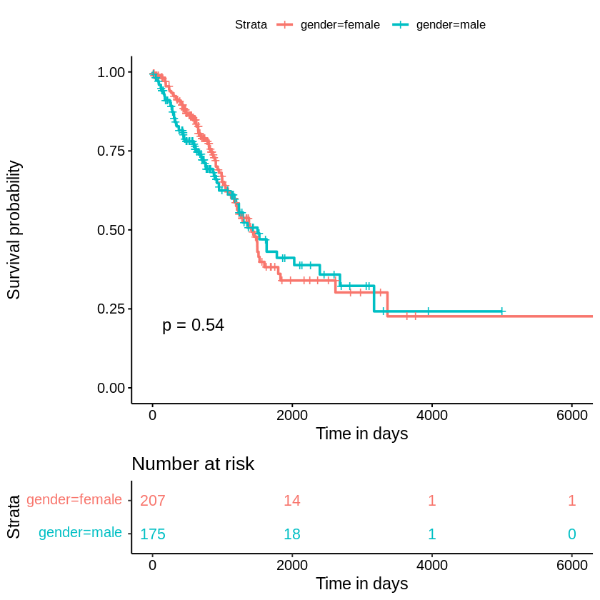

```r
# we produce a Kaplan Meier plot
ggsurvplot(fit, data=input_data_tr1, pval=TRUE, risk.table=TRUE, xlab="Time in days", risk.table.col="strata")
```

### Survival model based on Age group

Here, we are creating two group old >65 and young < 65 years, since mean age is 65

```r
#remove samples with no age information
input_data_tr3<-subset(input_data_tr1, age_at_index!="NA")

# Create age groups based of mean age (which is nearly 65)
age = as.data.frame(ifelse(input_data_tr3$age_at_index >= mean(as.numeric(input_data_tr3$age_at_index)), "Old", "Young"))
colnames(age) <- c("Age_Group")

#Add age group column to data
input_data_tr3 <- cbind(age,input_data_tr3)

head(input_data_tr3 )
```

A data.frame: 6 × 611

|  | Age_Group <chr> | id3 <chr> | tissue_type <chr> | age_at_index <int> | ethnicity <chr> | gender <chr> | race <chr> | vital_status <chr> | vital.time <int> | days_to_death <int> | ⋯ | ENSG00000152495.9 <chr> | ENSG00000244464.1 <chr> | ENSG00000237734.1 <chr> | ENSG00000249899.4 <chr> | ENSG00000277548.1 <chr> | ENSG00000271716.1 <chr> | ENSG00000226989.1 <chr> | ENSG00000259463.1 <chr> | ENSG00000267234.1 <chr> | ENSG00000182376.2 <chr> |
| --- | --- | --- | --- | --- | --- | --- | --- | --- | --- | --- | --- | --- | --- | --- | --- | --- | --- | --- | --- | --- | --- |
| TCGA-05-4249-01A | Old | TCGA-05-4249 | Cancer | 67 | NA | male | NA | Alive | 1523 | NA | ⋯ | -0.825 | -0.160 | -0.122 | 0.063 | -0.435 | -0.167 | -0.293 | -0.195 | -0.336 | -0.245 |
| TCGA-05-4382-01A | Old | TCGA-05-4382 | Cancer | 68 | NA | male | NA | Alive | 607 | NA | ⋯ | -0.697 | -0.160 | -0.208 | -0.179 | -0.428 | -0.198 | -0.293 | -0.195 | -0.226 | -0.337 |
| TCGA-05-4389-01A | Old | TCGA-05-4389 | Cancer | 70 | NA | male | NA | Alive | 1369 | NA | ⋯ | 0.039 | -0.160 | -0.208 | -0.376 | -0.838 | -0.165 | -0.122 | -0.195 | -0.336 | -0.422 |
| TCGA-05-4390-01A | Young | TCGA-05-4390 | Cancer | 58 | NA | female | NA | Alive | 1126 | NA | ⋯ | -1.072 | -0.160 | -0.208 | -0.376 | -0.941 | -0.278 | -0.293 | -0.195 | -0.040 | -0.422 |
| TCGA-05-4420-01A | Young | TCGA-05-4420 | Cancer | 41 | NA | male | NA | Alive | 912 | NA | ⋯ | -0.952 | -0.160 | -0.208 | -0.044 | -0.762 | -0.278 | -0.293 | -0.195 | -0.336 | -0.422 |
| TCGA-05-4426-01A | Old | TCGA-05-4426 | Cancer | 71 | NA | male | NA | Alive | 791 | NA | ⋯ | -0.827 | -0.160 | -0.143 | 0.081 | -0.085 | -0.034 | -0.293 | -0.195 | -0.336 | -0.378 |

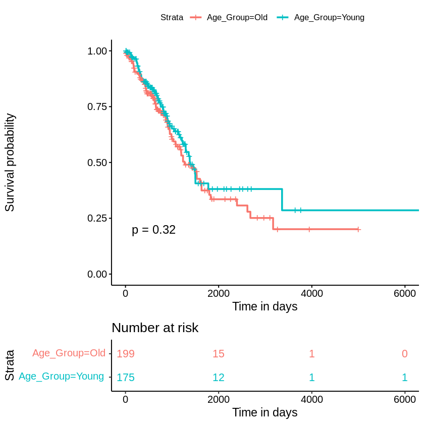

```r
#Create survival object
surv_object_a <- Surv(time = as.numeric(input_data_tr3$vital.time), event = input_data_tr3$OS)

#fit model
fit_a = survfit(surv_object_a ~ Age_Group, data=input_data_tr3)

# Kaplan Meier plot
ggsurvplot(fit_a, data=input_data_tr3, pval=TRUE, risk.table=TRUE, xlab="Time in days", risk.table.col="strata")
```

### Develop survival model for tumor stage

```r
#survival object
surv_object <- Surv(time = as.numeric(input_data_tr1$vital.time), event = input_data_tr1$OS)

# stage based
fit_s = survfit(surv_object ~ stage, data=input_data_tr1)

cox_s <-coxph(surv_object ~ stage, data=input_data_tr1)
```

Create kaplan-meier plot to visualize the startifcation of risk groups

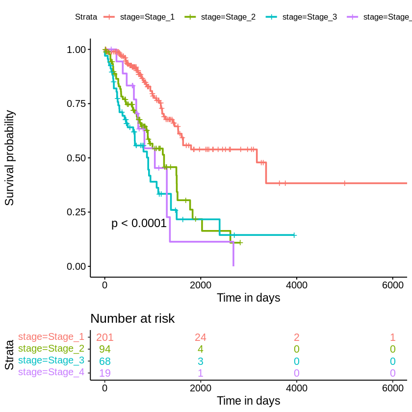

```r
# we produce a Kaplan Meier plot
ggsurvplot(fit_s, data=input_data_tr1, pval=TRUE, risk.table=TRUE, xlab="Time in days", risk.table.col="stage")
```

### Devevlop model for smoking history

```r
#remove samples where cigarettes information is missing
input_data_tr2<-subset(input_data_tr1,cigarettes_per_day!="NA")

# Create age groups based of mean age (which is nearly 65)
smoking = as.data.frame(ifelse(input_data_tr2$cigarettes_per_day >= mean(as.numeric(input_data_tr2$cigarettes_per_day)), "High", "Low"))
colnames(smoking) <- c("smoking")

#Add age group column to data
input_data_tr2 <- cbind(smoking,input_data_tr2)

head(input_data_tr2,5)
```

A data.frame: 5 × 611

|  | smoking <chr> | id3 <chr> | tissue_type <chr> | age_at_index <int> | ethnicity <chr> | gender <chr> | race <chr> | vital_status <chr> | vital.time <int> | days_to_death <int> | ⋯ | ENSG00000152495.9 <chr> | ENSG00000244464.1 <chr> | ENSG00000237734.1 <chr> | ENSG00000249899.4 <chr> | ENSG00000277548.1 <chr> | ENSG00000271716.1 <chr> | ENSG00000226989.1 <chr> | ENSG00000259463.1 <chr> | ENSG00000267234.1 <chr> | ENSG00000182376.2 <chr> |
| --- | --- | --- | --- | --- | --- | --- | --- | --- | --- | --- | --- | --- | --- | --- | --- | --- | --- | --- | --- | --- | --- |
| TCGA-05-4249-01A | High | TCGA-05-4249 | Cancer | 67 | NA | male | NA | Alive | 1523 | NA | ⋯ | -0.825 | -0.160 | -0.122 | 0.063 | -0.435 | -0.167 | -0.293 | -0.195 | -0.336 | -0.245 |
| TCGA-05-4382-01A | High | TCGA-05-4382 | Cancer | 68 | NA | male | NA | Alive | 607 | NA | ⋯ | -0.697 | -0.160 | -0.208 | -0.179 | -0.428 | -0.198 | -0.293 | -0.195 | -0.226 | -0.337 |
| TCGA-05-4389-01A | High | TCGA-05-4389 | Cancer | 70 | NA | male | NA | Alive | 1369 | NA | ⋯ | 0.039 | -0.160 | -0.208 | -0.376 | -0.838 | -0.165 | -0.122 | -0.195 | -0.336 | -0.422 |
| TCGA-05-4390-01A | Low | TCGA-05-4390 | Cancer | 58 | NA | female | NA | Alive | 1126 | NA | ⋯ | -1.072 | -0.160 | -0.208 | -0.376 | -0.941 | -0.278 | -0.293 | -0.195 | -0.040 | -0.422 |
| TCGA-05-4420-01A | Low | TCGA-05-4420 | Cancer | 41 | NA | male | NA | Alive | 912 | NA | ⋯ | -0.952 | -0.160 | -0.208 | -0.044 | -0.762 | -0.278 | -0.293 | -0.195 | -0.336 | -0.422 |

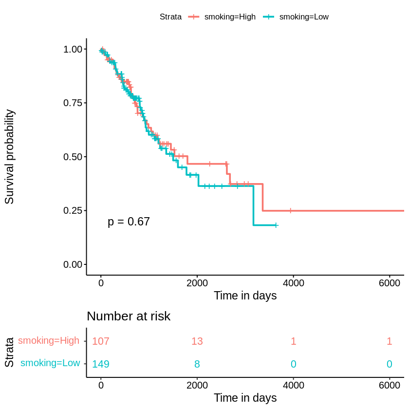

```r
#Create survival object
surv_object_sm <- Surv(time = as.numeric(input_data_tr2$vital.time), event = input_data_tr2$OS)

#fit model
fit_sm = survfit(surv_object_sm ~ smoking, data=input_data_tr2)

# Kaplan Meier plot
ggsurvplot(fit_sm, data=input_data_tr2, pval=TRUE, risk.table=TRUE, xlab="Time in days", risk.table.col="strata")
```

From the Univariate survival analysis based on few Clinical factors, it has been observed tumor stage is key prognostic factor for LUAD patients with p-value < 0.01.

Gender, age group and smoking (cigeretes) factors are not significant prognostic factors.

Thus, next we need to find molecular signature as prognostic factors

### Univariate Survival analysis for Molecular/transcriptomics features

Here, we will perform univariate survival analysis for selected transcriptomics features.

We will perform univariate survival analysis on each feature in the data employing `for` loop using COXPH model

Here, I am also applying (log rank test) p-value (< 0.05) filetr criteria to filter only significant genes, eventually we are writing results into a file

```r
# create a file to store results
write.table(cbind("Gene","Beta","HR","P-value","GP1","GP2","Hr-Inv-lst","Concordance","Std_Error"),
            file="OS-final-HRmedian-quantright.csv",row.names=F,col.names=F,sep = ',');

#Here features to compute survival start from 17th column onwards, which is transcriptomics features

for(i in seq(from=17, to=length(input_data_tr1), by=1))
{
  surv_object2 <- Surv(time = input_data_tr1$vital.time, event = input_data_tr1$OS)

#survival analysis: fits cox ph model to find HR for median cut
  fit1 <- survfit(surv_object2 ~ (input_data_tr1[,i])>(median(input_data_tr1[1,i])), data=input_data_tr1);
  summary(fit1);
  fit1.coxph <- coxph(surv_object2 ~ (input_data_tr1[,i])>(median(input_data_tr1[1,i])), data = input_data_tr1)
# summary(fit1.coxph);
  first <- coef(summary(fit1.coxph))

#check whether the pvalue is significant (< 0.05) or not
  if((first[5]<=0.05)&&(!is.na(first[5]))&&(!is.na(first[2])))
  {write.table(cbind(colnames(input_data_tr1[i]),first[1],first[2],first[5],fit1$n[1],fit1$n[2],1/first[2],fit1.coxph$concordance[6],fit1.coxph$concordance[7]),
               file="OS-final-HRmedian-quantright.csv",row.names=F,col.names=F,sep = ',',append = T);#output file
  }
}
```

Now, let's see the univariate survival analysis results based on molecular/transcriptomics features.

```r
Surv_res <- read.table("OS-final-HRmedian-quantright.csv", sep=",", header=TRUE, row.names=1)
dim(Surv_res)
head(Surv_res)
```

1. 56

2. 8

A data.frame: 6 × 8

|  | Beta <dbl> | HR <dbl> | P.value <dbl> | GP1 <int> | GP2 <int> | Hr.Inv.lst <dbl> | Concordance <dbl> | Std_Error <dbl> |
| --- | --- | --- | --- | --- | --- | --- | --- | --- |
| ENSG00000273797.1 | 0.6230904 | 1.864682 | 0.0025351948 | 328 | 54 | 0.5362845 | 0.5564985 | 0.02026279 |
| ENSG00000269806.1 | 0.5763657 | 1.779559 | 0.0007110813 | 199 | 183 | 0.5619369 | 0.5698743 | 0.02352446 |
| ENSG00000253953.2 | 0.3787163 | 1.460409 | 0.0399832945 | 289 | 93 | 0.6847399 | 0.5300052 | 0.02119552 |
| ENSG00000223653.4 | 0.4087640 | 1.504956 | 0.0225879892 | 140 | 242 | 0.6644710 | 0.5508693 | 0.02179521 |
| ENSG00000259915.2 | 0.4741341 | 1.606622 | 0.0375894113 | 336 | 46 | 0.6224238 | 0.5179033 | 0.01598069 |
| ENSG00000261226.1 | 0.4536065 | 1.573979 | 0.0274864015 | 115 | 267 | 0.6353327 | 0.5378551 | 0.02074515 |

Sort features based on concordance index

```r
# Sort features based on Corcordance
CI_features <- as.data.frame(Surv_res[order(Surv_res[,"Concordance"], decreasing =  TRUE),])
dim(CI_features)
head(CI_features)
```

1. 56

2. 8

A data.frame: 6 × 8

|  | Beta <dbl> | HR <dbl> | P.value <dbl> | GP1 <int> | GP2 <int> | Hr.Inv.lst <dbl> | Concordance <dbl> | Std_Error <dbl> |
| --- | --- | --- | --- | --- | --- | --- | --- | --- |
| ENSG00000270806.1 | 0.5036575 | 1.654763 | 2.954669e-03 | 195 | 187 | 0.6043163 | 0.5869169 | 0.02285677 |
| ENSG00000226533.1 | 0.8045472 | 2.235684 | 1.111443e-04 | 129 | 253 | 0.4472904 | 0.5862111 | 0.01947493 |
| ENSG00000256069.6 | 0.6824047 | 1.978630 | 4.900799e-05 | 234 | 148 | 0.5054002 | 0.5793252 | 0.02367870 |
| ENSG00000250878.3 | 0.5208832 | 1.683514 | 1.971607e-03 | 254 | 128 | 0.5939957 | 0.5775521 | 0.02364762 |
| ENSG00000224727.1 | 0.5313684 | 1.701259 | 1.533004e-03 | 231 | 151 | 0.5878001 | 0.5708556 | 0.02376146 |
| ENSG00000269806.1 | 0.5763657 | 1.779559 | 7.110813e-04 | 199 | 183 | 0.5619369 | 0.5698743 | 0.02352446 |

56 genes found to be significant (p-value < 0.05) prognostic factors based on univariate survival analysis. Top 6 genes based on the Concordance index reprsented in the above table.

## Analyze Prognostic factors

From the univariate analysis, 56 genes, and tumor stage found to be significant prognostic factor. Next, it would be intersting to understand whether are good or bad prognostic factor. We can also apply more stringent criterias (HR (**Hazard ratio, Concordance Index**) to further filter or reduce signatures.

Here, I am applying HR criteria to reduce and understand the impact on prognosis. I will assign gene as bad prognostic factor (HR >1.2) and good prognostic factor Inverse_of_HR >1.2

```r
#Bad Prognostic features based on HR >1.2
sig_surv_features <- CI_features[CI_features$Concordance >= 0.55, ]
dim(sig_surv_features)

survival_unfavorable <- sig_surv_features[sig_surv_features$HR >= 1.2, ]

dim(survival_unfavorable)
head(survival_unfavorable)
```

1. 23

2. 8

1. 23

2. 8

A data.frame: 6 × 8

|  | Beta <dbl> | HR <dbl> | P.value <dbl> | GP1 <int> | GP2 <int> | Hr.Inv.lst <dbl> | Concordance <dbl> | Std_Error <dbl> |
| --- | --- | --- | --- | --- | --- | --- | --- | --- |
| ENSG00000270806.1 | 0.5036575 | 1.654763 | 2.954669e-03 | 195 | 187 | 0.6043163 | 0.5869169 | 0.02285677 |
| ENSG00000226533.1 | 0.8045472 | 2.235684 | 1.111443e-04 | 129 | 253 | 0.4472904 | 0.5862111 | 0.01947493 |
| ENSG00000256069.6 | 0.6824047 | 1.978630 | 4.900799e-05 | 234 | 148 | 0.5054002 | 0.5793252 | 0.02367870 |
| ENSG00000250878.3 | 0.5208832 | 1.683514 | 1.971607e-03 | 254 | 128 | 0.5939957 | 0.5775521 | 0.02364762 |
| ENSG00000224727.1 | 0.5313684 | 1.701259 | 1.533004e-03 | 231 | 151 | 0.5878001 | 0.5708556 | 0.02376146 |
| ENSG00000269806.1 | 0.5763657 | 1.779559 | 7.110813e-04 | 199 | 183 | 0.5619369 | 0.5698743 | 0.02352446 |

```r
#Good Prognostic features based on inverse of HR >1.2
survival_favorable <- sig_surv_features[sig_surv_features$Hr.Inv.lst >= 1.2, ]
dim(survival_favorable)
head(survival_favorable)
```

1. 0

2. 8

A data.frame: 0 × 8

| Beta | HR | P.value | GP1 | GP2 | Hr.Inv.lst | Concordance | Std_Error |
| --- | --- | --- | --- | --- | --- | --- | --- |
| <dbl> | <dbl> | <dbl> | <int> | <int> | <dbl> | <dbl> | <dbl> |

After applying filter criteria, we found 23 genes as significant bad prognostic factors and none of genes able to pass filter criteria for good prognostic factor

### Gene Annotation

After identifying significant prognostic genes. It is also important we must be able annotate to undrstand what are these transcripts . Here, I am using `org.Hs.eg.db` package to annotate our genes. We can also perform annotatation using other databases as well.

```r
#install package
if (!requireNamespace("BiocManager", quietly = TRUE))
    install.packages("BiocManager")

BiocManager::install("org.Hs.eg.db")
```

```r
library(org.Hs.eg.db)
keytypes(org.Hs.eg.db)
```

1. 'ACCNUM'

2. 'ALIAS'

3. 'ENSEMBL'

4. 'ENSEMBLPROT'

5. 'ENSEMBLTRANS'

6. 'ENTREZID'

7. 'ENZYME'

8. 'EVIDENCE'

9. 'EVIDENCEALL'

10. 'GENENAME'

11. 'GENETYPE'

12. 'GO'

13. 'GOALL'

14. 'IPI'

15. 'MAP'

16. 'OMIM'

17. 'ONTOLOGY'

18. 'ONTOLOGYALL'

19. 'PATH'

20. 'PFAM'

21. 'PMID'

22. 'PROSITE'

23. 'REFSEQ'

24. 'SYMBOL'

25. 'UCSCKG'

26. 'UNIPROT'

```r
#check names of columns that we have in database
columns(org.Hs.eg.db)
```

1. 'ACCNUM'

2. 'ALIAS'

3. 'ENSEMBL'

4. 'ENSEMBLPROT'

5. 'ENSEMBLTRANS'

6. 'ENTREZID'

7. 'ENZYME'

8. 'EVIDENCE'

9. 'EVIDENCEALL'

10. 'GENENAME'

11. 'GENETYPE'

12. 'GO'

13. 'GOALL'

14. 'IPI'

15. 'MAP'

16. 'OMIM'

17. 'ONTOLOGY'

18. 'ONTOLOGYALL'

19. 'PATH'

20. 'PFAM'

21. 'PMID'

22. 'PROSITE'

23. 'REFSEQ'

24. 'SYMBOL'

25. 'UCSCKG'

26. 'UNIPROT'

```r
#column we want to extract
#cols <- c("SYMBOL", "ENTREZID", "GENETYPE", "GOALL", "ONTOLOGY", "PATH")

cols <- c("SYMBOL", "ENTREZID", "GENETYPE", "GENENAME")
```

```r
#get all important features as characters
CI_f<- as.character(row.names(CI_features))

# convert ensemble transcript IDs to ensemble IDs (since, above database have information regarding only ensemble)
CI_f1 <- gsub("\\.[0-9]*$", "", CI_f)
```

```r
# Perform annotation
annotated_genes <- as.data.frame(select(org.Hs.eg.db, keys=CI_f1, columns=cols, keytype="ENSEMBL"))
head(annotated_genes, 20)
```

A data.frame: 20 × 5

|  | ENSEMBL <chr> | SYMBOL <chr> | ENTREZID <chr> | GENETYPE <chr> | GENENAME <chr> |
| --- | --- | --- | --- | --- | --- |
| 1 | ENSG00000270806 | C17orf50 | 146853 | protein-coding | chromosome 17 open reading frame 50 |
| 2 | ENSG00000226533 | BTBD9-AS1 | 101929425 | ncRNA | BTBD9 antisense RNA 1 |
| 3 | ENSG00000256069 | A2MP1 | 3 | pseudo | alpha-2-macroglobulin pseudogene 1 |
| 4 | ENSG00000250878 | METTL21EP | 121952 | pseudo | methyltransferase like 21E, pseudogene |
| 5 | ENSG00000224727 | NA | NA | NA | NA |
| 6 | ENSG00000269806 | NA | NA | NA | NA |
| 7 | ENSG00000278909 | NA | NA | NA | NA |
| 8 | ENSG00000242307 | NA | NA | NA | NA |
| 9 | ENSG00000235033 | DAAM2-AS1 | 100505635 | ncRNA | DAAM2 antisense RNA 1 |
| 10 | ENSG00000272754 | NA | NA | NA | NA |
| 11 | ENSG00000229948 | NA | NA | NA | NA |
| 12 | ENSG00000249717 | PARM1-AS1 | 100507388 | ncRNA | PARM1 antisense RNA 1 |
| 13 | ENSG00000122432 | SPATA1 | 100505741 | protein-coding | spermatogenesis associated 1 |
| 14 | ENSG00000273797 | NA | NA | NA | NA |
| 15 | ENSG00000260249 | NA | NA | NA | NA |
| 16 | ENSG00000231875 | NA | NA | NA | NA |
| 17 | ENSG00000258527 | NA | NA | NA | NA |
| 18 | ENSG00000264384 | RN7SL431P | 106866913 | pseudo | RNA, 7SL, cytoplasmic 431, pseudogene |
| 19 | ENSG00000265118 | NA | NA | NA | NA |
| 20 | ENSG00000229839 | NA | NA | NA | NA |

**Draw KM plot for a specific gene**

```r
#Extract gene expression data for that gene
gene1 <- input_data_tr1$ENSG00000226533.1

#extract survival  information
os <- input_data_tr1$OS
os.time <- input_data_tr1$vital.time

# create a new column regulation status for the gene based on the cut of median value
reg_status = as.data.frame(ifelse(input_data_tr1$ENSG00000226533.1 >= median(as.numeric(input_data_tr1$ENSG00000226533.1)), "Upreg", "Down_reg"))

# add column name
colnames(reg_status) <- c("Reg_status")

#combine information together to create a new data frame
gene1_data <- cbind(gene1,os, os.time, reg_status)

#print top rows
head(gene1_data)
```

A data.frame: 6 × 4

|  | gene1 <chr> | os <dbl> | os.time <int> | Reg_status <chr> |
| --- | --- | --- | --- | --- |
| 1 | -0.138 | 0 | 1523 | Down_reg |
| 2 | -0.269 | 0 | 607 | Upreg |
| 3 | -0.251 | 0 | 1369 | Upreg |
| 4 | -0.087 | 0 | 1126 | Down_reg |
| 5 | -0.267 | 0 | 912 | Upreg |
| 6 | -0.312 | 0 | 791 | Upreg |

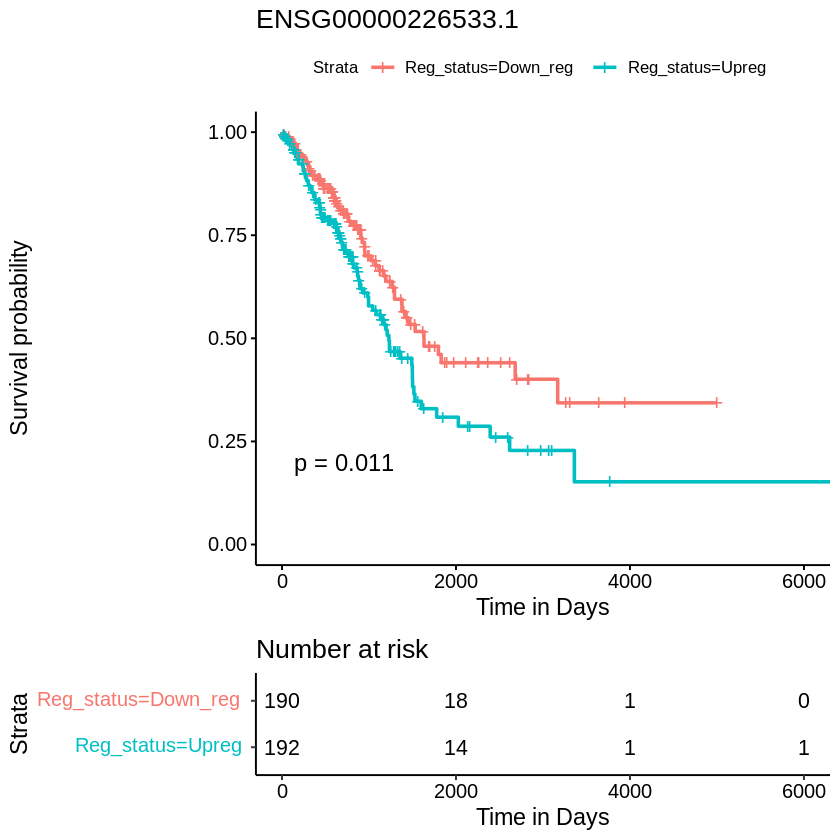

```r
#create survival object
surv_object2 <- Surv(time = gene1_data$os.time, event = gene1_data$os)

#fit model
fit_G <- survfit(surv_object2 ~ Reg_status , data=gene1_data)

#Draw KM plot
ggsurvplot(fit_G, data=gene1_data, pval=TRUE, xlab="Time in Days", risk.table=TRUE, title="ENSG00000226533.1")
```

## Multivariate Prognostic models

From the univariate analysis, we are able to identify 23 genes and stage as significant prognostic factors.

To understand whether these genes (top 6) and clinical factors also act as independent prognostic factor. We need to develop multivariate survival analysis.

Manipulate genes Ids (replace digits after decimals with none, since, code is not able to take it's original name as numeric factor)

```r
nm <- names(input_data_tr1)
nm2 <- gsub("\\.[0-9]*$", "", nm)

# Recreate data with substituted column names
ip <- input_data_tr1
colnames(ip) <- nm2

#Print top rows
head(ip [16:20],5)
```

A data.frame: 5 × 5

|  | stage_n <dbl> | ENSG00000259883 <chr> | ENSG00000231981 <chr> | ENSG00000263089 <chr> | ENSG00000233540 <chr> |
| --- | --- | --- | --- | --- | --- |
| TCGA-05-4249-01A | 1 | -0.068 | -0.121 | -0.085 | 1.450 |
| TCGA-05-4382-01A | 1 | -0.353 | -0.157 | -0.468 | 0.129 |
| TCGA-05-4389-01A | 1 | -0.362 | -0.250 | -0.491 | -0.040 |
| TCGA-05-4390-01A | 1 | -0.367 | -0.250 | -0.472 | -0.455 |
| TCGA-05-4420-01A | 1 | -0.234 | -0.250 | -0.320 | -0.455 |

```r
head(survival_unfavorable)
```

A data.frame: 6 × 8

|  | Beta <dbl> | HR <dbl> | P.value <dbl> | GP1 <int> | GP2 <int> | Hr.Inv.lst <dbl> | Concordance <dbl> | Std_Error <dbl> |
| --- | --- | --- | --- | --- | --- | --- | --- | --- |
| ENSG00000270806.1 | 0.5036575 | 1.654763 | 2.954669e-03 | 195 | 187 | 0.6043163 | 0.5869169 | 0.02285677 |
| ENSG00000226533.1 | 0.8045472 | 2.235684 | 1.111443e-04 | 129 | 253 | 0.4472904 | 0.5862111 | 0.01947493 |
| ENSG00000256069.6 | 0.6824047 | 1.978630 | 4.900799e-05 | 234 | 148 | 0.5054002 | 0.5793252 | 0.02367870 |
| ENSG00000250878.3 | 0.5208832 | 1.683514 | 1.971607e-03 | 254 | 128 | 0.5939957 | 0.5775521 | 0.02364762 |
| ENSG00000224727.1 | 0.5313684 | 1.701259 | 1.533004e-03 | 231 | 151 | 0.5878001 | 0.5708556 | 0.02376146 |
| ENSG00000269806.1 | 0.5763657 | 1.779559 | 7.110813e-04 | 199 | 183 | 0.5619369 | 0.5698743 | 0.02352446 |

### Multivariate model

First develop multivariate model with clinical factor and top molecular features (based on CI value)

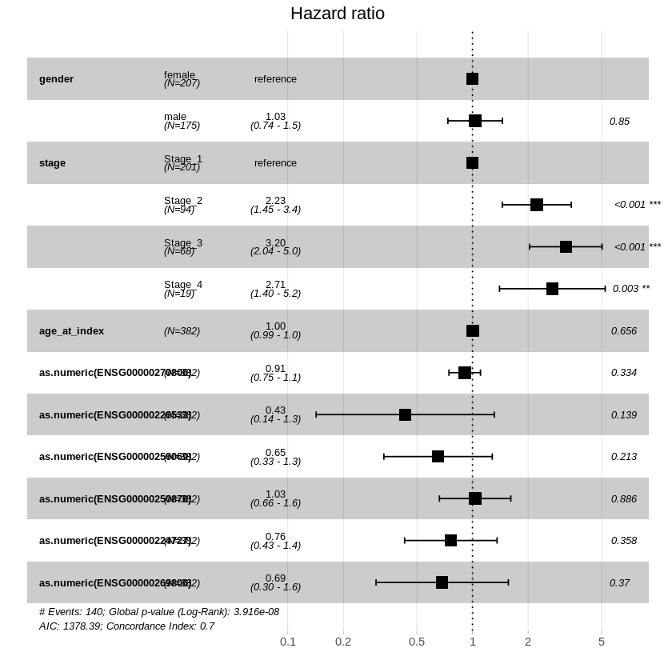

```r
# Fit a Cox proportional hazards model
surv_object_n <- Surv(time = ip$vital.time, event = ip$OS)
fit.coxph <- coxph(surv_object_n ~   gender + stage + age_at_index + as.numeric(ENSG00000270806) + as.numeric(ENSG00000226533) + as.numeric(ENSG00000256069) + as.numeric(ENSG00000250878) + as.numeric(ENSG00000224727)+ as.numeric(ENSG00000269806) , data = ip )
ggforest(fit.coxph, data = ip)
```

From the multivariate analysis, we observed tumor stage is only significant prognostic factor, while none of the top 6 genes independently acts as significant prognostic factor.

Thus, we need to design better prognostic molecular signature. One approach is that we can develop PI (prognostic Index model), where we can combine multiple genes (considering their Coefficients values in univariate analysis)

`Coeff of gene1 * expression of Gene1 + Coeff of gene2 * expression of Gene2 + ... + Coeff of geneN * expression of GeneN`

Here, I am using same top six genes to build PI model

```r
head(survival_unfavorable)
```

A data.frame: 6 × 8

|  | Beta <dbl> | HR <dbl> | P.value <dbl> | GP1 <int> | GP2 <int> | Hr.Inv.lst <dbl> | Concordance <dbl> | Std_Error <dbl> |
| --- | --- | --- | --- | --- | --- | --- | --- | --- |
| ENSG00000270806.1 | 0.5036575 | 1.654763 | 2.954669e-03 | 195 | 187 | 0.6043163 | 0.5869169 | 0.02285677 |
| ENSG00000226533.1 | 0.8045472 | 2.235684 | 1.111443e-04 | 129 | 253 | 0.4472904 | 0.5862111 | 0.01947493 |
| ENSG00000256069.6 | 0.6824047 | 1.978630 | 4.900799e-05 | 234 | 148 | 0.5054002 | 0.5793252 | 0.02367870 |
| ENSG00000250878.3 | 0.5208832 | 1.683514 | 1.971607e-03 | 254 | 128 | 0.5939957 | 0.5775521 | 0.02364762 |
| ENSG00000224727.1 | 0.5313684 | 1.701259 | 1.533004e-03 | 231 | 151 | 0.5878001 | 0.5708556 | 0.02376146 |
| ENSG00000269806.1 | 0.5763657 | 1.779559 | 7.110813e-04 | 199 | 183 | 0.5619369 | 0.5698743 | 0.02352446 |

### Prognostic Index (PI) model with top 6 genes

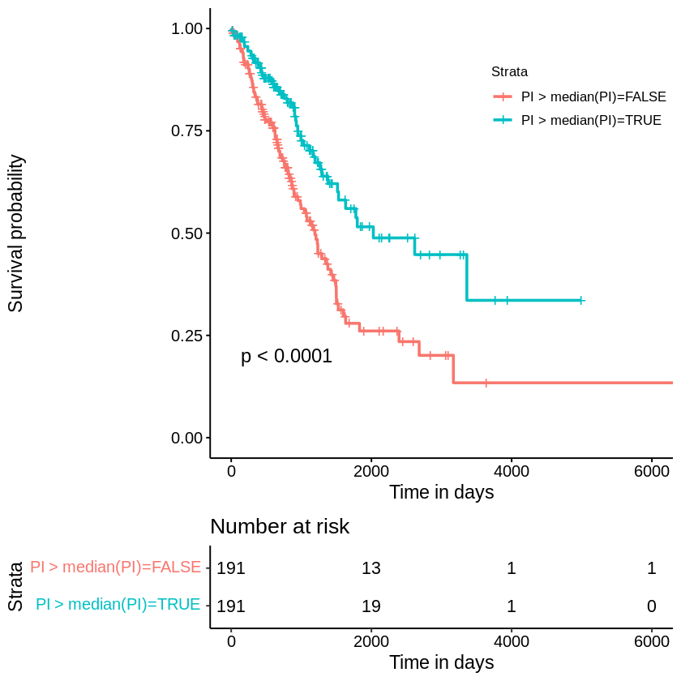

```r
PI=0

PI= PI + as.numeric(ip$ENSG00000270806)*0.504 + as.numeric(ip$ENSG00000226533)*0.805 + as.numeric(ip$ENSG00000256069)*0.682 + as.numeric(ip$ENSG00000250878)*0.521 + as.numeric(ip$ENSG00000224727)*0.531+ as.numeric(ip$ENSG00000269806)*0.576

ip$PI<-PI

surv_object_p <- Surv(time = ip$vital.time, event = ip$OS)

fit <- survfit(surv_object_p~(ip$PI>median(ip$PI)), data=ip)
ggsurvplot(fit, pval = TRUE, censor = TRUE, conf.int = F, xlab = "Time in days",  legend=c(0.8,0.8), risk.table=TRUE)
```

Multivariate model with PI model

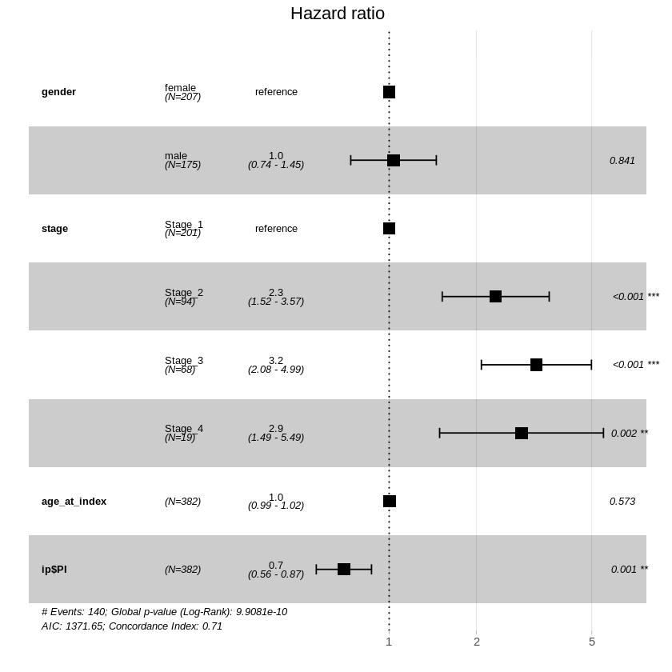

```r
# Fit a Cox proportional hazards model
surv_object_n <- Surv(time = ip$vital.time, event = ip$OS)
fit.coxph <- coxph(surv_object_n ~   gender + stage + age_at_index + ip$PI, data = ip )
ggforest(fit.coxph, data = ip)
```

PI model acts as significant prognostic factor both as univariate and multivariate models

Note: we can develop PI models with different combinations of features to obtain best model for publication purpose

**Draw Boxplot for top genes**

```r
g1 <- as.data.frame(as.numeric(ip$ENSG00000270806))
g2 <- as.data.frame(as.numeric(ip$ENSG00000226533))
g3 <- as.data.frame(as.numeric(ip$ENSG00000256069))
g4 <- as.data.frame(as.numeric(ip$ENSG00000250878))
g5 <- as.data.frame(as.numeric(ip$ENSG00000224727))
g6 <- as.data.frame(as.numeric(ip$ENSG00000269806))


# create a new column risk status based on PI median value
Risk_status <- as.data.frame(ifelse(ip$PI >= median(as.numeric(ip$PI)), "High_Risk", "Low_Risk"))

#combine risk status with gene expression of key genes
new_data <- cbind(Risk_status, g1,g2,g3,g4,g5,g6)

# add column name
colnames(new_data) <- c("Risk", "ENSG00000270806", "ENSG00000226533", "ENSG00000256069", "ENSG00000250878", "ENSG00000224727", "ENSG00000269806")

# view top rows
head(new_data,4)
```

A data.frame: 4 × 7

|  | Risk <chr> | ENSG00000270806 <dbl> | ENSG00000226533 <dbl> | ENSG00000256069 <dbl> | ENSG00000250878 <dbl> | ENSG00000224727 <dbl> | ENSG00000269806 <dbl> |
| --- | --- | --- | --- | --- | --- | --- | --- |
| 1 | Low_Risk | -0.360 | -0.138 | -0.307 | -0.415 | -0.308 | -0.244 |
| 2 | Low_Risk | -0.428 | -0.269 | -0.292 | -0.359 | -0.288 | -0.326 |
| 3 | Low_Risk | -0.719 | -0.251 | -0.303 | -0.317 | -0.569 | -0.243 |
| 4 | Low_Risk | -0.888 | -0.087 | -0.400 | -0.509 | -0.312 | -0.167 |

Draw boxplot for these 6 genes and visualize the expression pattern among high and low risk groups

```r
#install required package to shape dataframe
install.packages("reshape")
```

```r
library("reshape")
```

```r
#melt dataframe
df_m<- melt(new_data)
```

```r
head(df_m,5)
```

A data.frame: 5 × 3

|  | Risk <chr> | variable <fct> | value <dbl> |
| --- | --- | --- | --- |
| 1 | Low_Risk | ENSG00000270806 | -0.360 |
| 2 | Low_Risk | ENSG00000270806 | -0.428 |
| 3 | Low_Risk | ENSG00000270806 | -0.719 |
| 4 | Low_Risk | ENSG00000270806 | -0.888 |
| 5 | Low_Risk | ENSG00000270806 | -0.723 |

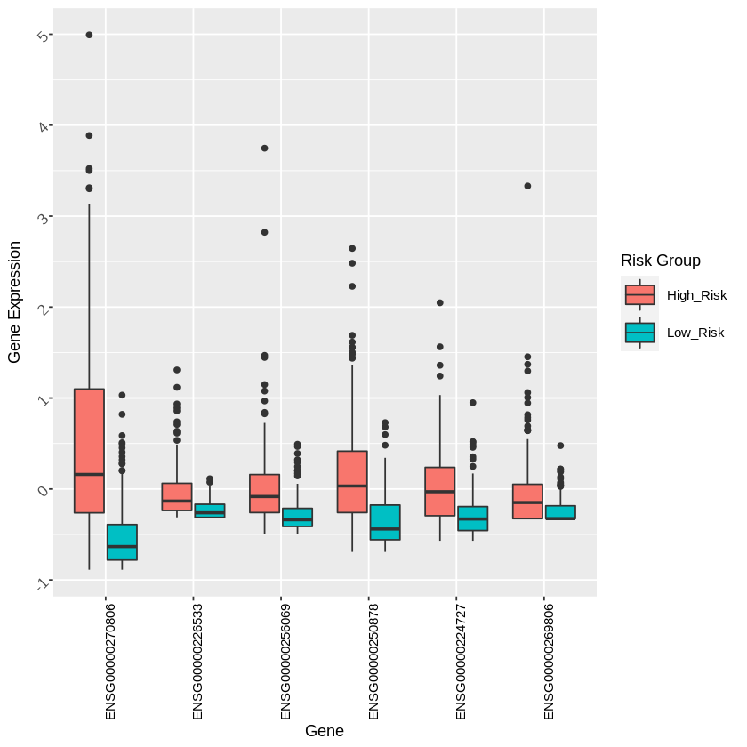

```r
#create boxplot
b <- ggplot(df_m, aes(factor(variable), value)) + geom_boxplot(aes(fill = Risk))

#Add axis title, legend title and adjust font size
b + theme(legend.key.size = unit(0.9, "cm"), legend.text = element_text(color= "Black", size= 9), axis.text.x = element_text(color= "Black", size= 9, angle= 90), axis.text.y = element_text(size= 10, angle= 45)) + xlab("Gene") + ylab("Gene Expression") + labs(fill = "Risk Group")
```

## Model Evaluation on test data

For final validation, we must be validate our prognostic models on an independent dataset, which was not used during the feature selection and training or development of the model.

Here, I am using 20% data from the full data as test data

Prepare test data for survival analysis

```r
#remove samples where OS.time is NA
input_data_te1<-subset(sel_te,vital.time!="NA")

#Check dimensions of data
dim(input_data_te1)
```

1. 100

2. 610

```r
names1 <- names(input_data_te1)
names2 <- gsub("\\.[0-9]*$", "", names1)

te_ip <- input_data_te1
colnames(te_ip) <- names2

dim(te_ip)
head(te_ip, 5)
```

1. 100

2. 610

A data.frame: 5 × 610

|  | id3 <chr> | tissue_type <chr> | age_at_index <int> | ethnicity <chr> | gender <chr> | race <chr> | vital_status <chr> | vital.time <int> | days_to_death <int> | days_to_last_follow_up <int> | ⋯ | ENSG00000152495 <chr> | ENSG00000244464 <chr> | ENSG00000237734 <chr> | ENSG00000249899 <chr> | ENSG00000277548 <chr> | ENSG00000271716 <chr> | ENSG00000226989 <chr> | ENSG00000259463 <chr> | ENSG00000267234 <chr> | ENSG00000182376 <chr> |
| --- | --- | --- | --- | --- | --- | --- | --- | --- | --- | --- | --- | --- | --- | --- | --- | --- | --- | --- | --- | --- | --- |
| TCGA-05-4417-01A | TCGA-05-4417 | Cancer | 51 | NA | female | NA | Alive | 455 | NA | 455 | ⋯ | 0.583 | -0.160 | 0.260 | -0.037 | -0.193 | -0.278 | -0.293 | 0.019 | -0.336 | -0.309 |
| TCGA-05-4422-01A | TCGA-05-4422 | Cancer | 68 | NA | male | NA | Alive | 365 | NA | 365 | ⋯ | 0.445 | -0.160 | -0.137 | -0.226 | -0.037 | -0.097 | -0.293 | -0.195 | -0.210 | -0.229 |
| TCGA-35-4122-01A | TCGA-35-4122 | Cancer | 69 | not hispanic or latino | male | white | Alive | 225 | NA | 225 | ⋯ | -0.684 | -0.160 | -0.208 | -0.376 | -1.326 | -0.278 | -0.293 | -0.058 | -0.336 | -0.422 |
| TCGA-38-4625-01A | TCGA-38-4625 | Cancer | 66 | not hispanic or latino | female | white | Alive | 2973 | NA | 2973 | ⋯ | -0.935 | -0.100 | -0.208 | -0.313 | -0.871 | -0.203 | -0.293 | -0.195 | -0.336 | -0.342 |
| TCGA-38-4631-01A | TCGA-38-4631 | Cancer | 72 | not hispanic or latino | female | white | Dead | 354 | 354 | NA | ⋯ | -0.990 | -0.160 | -0.208 | -0.376 | -1.326 | -0.278 | -0.293 | -0.195 | -0.336 | -0.422 |

```
Call: survfit(formula = surv_object1 ~ stage, data = input_data_te1)

               n events median 0.95LCL 0.95UCL
stage=Stage_1 54     14     NA    1258      NA
stage=Stage_2 25     11    995     582      NA
stage=Stage_3 16      9   1265     336      NA
stage=Stage_4  5      4    976     167      NA
```

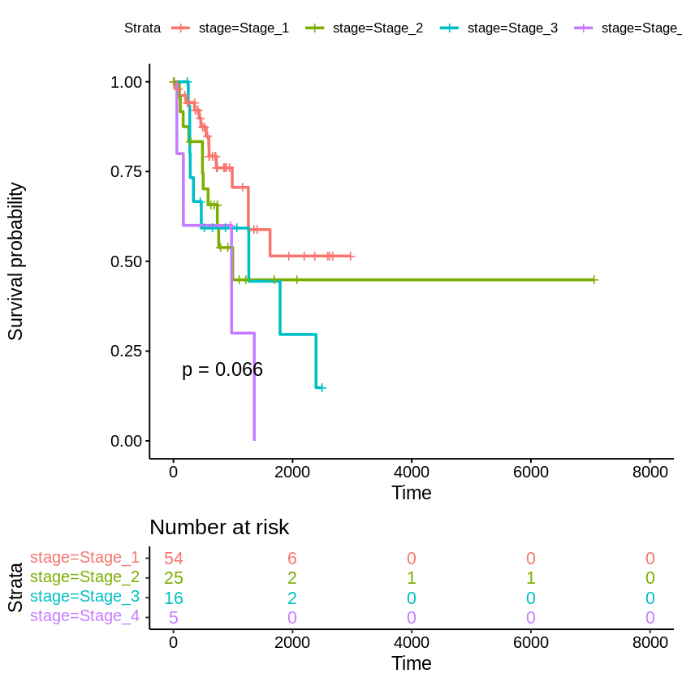

```r
# stage based
surv_object1 <- Surv(time = as.numeric(input_data_te1$vital.time), event = input_data_te1$OS)
fit_s1 = survfit(surv_object1 ~ stage, data=input_data_te1)

print(fit_s1)
# we produce a Kaplan Meier plot
ggsurvplot(fit_s1, data=input_data_te1, pval=TRUE, risk.table=TRUE, risk.table.col="stage")
```

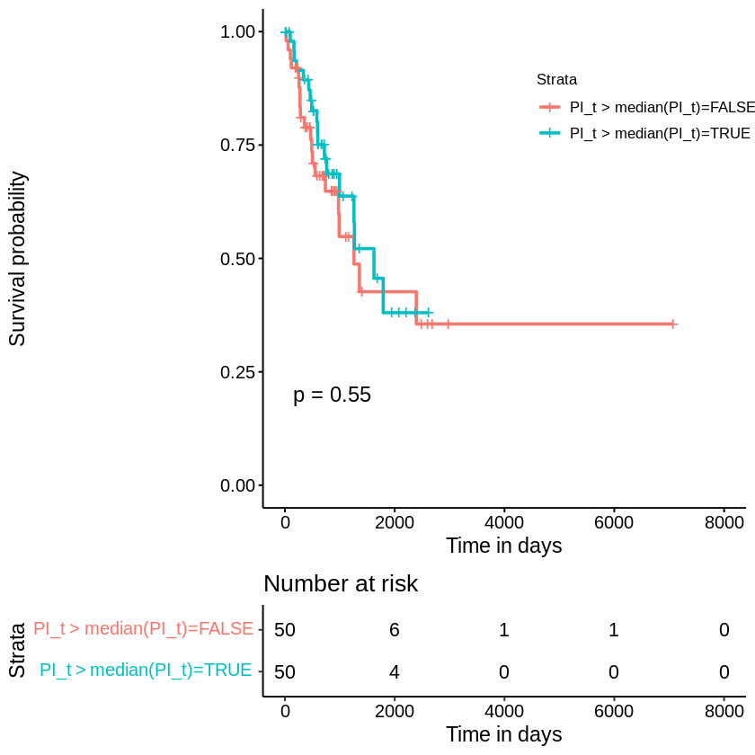

```r
#PI model
PI_t=0
PI_t= PI_t +  as.numeric(te_ip$ENSG00000270806)*0.504 + as.numeric(te_ip$ENSG00000226533)*0.805 + as.numeric(te_ip$ENSG00000256069)*0.682 + as.numeric(te_ip$ENSG00000250878)*0.521 + as.numeric(te_ip$ENSG00000224727)*0.531+ as.numeric(te_ip$ENSG00000269806)*0.576

te_ip$PI_t<-PI_t
surv_object_p_t <- Surv(time = te_ip$vital.time, event = te_ip$OS)

fit_t <- survfit(surv_object_p_t~(te_ip$PI_t>median(te_ip$PI_t)), data=te_ip)
ggsurvplot(fit_t, pval = TRUE, censor = TRUE, conf.int = F, xlab = "Time in days",  legend=c(0.8,0.8), risk.table=TRUE)
```

```r
head(ip)
```

A data.frame: 6 × 611

|  | id3 <chr> | tissue_type <chr> | age_at_index <int> | ethnicity <chr> | gender <chr> | race <chr> | vital_status <chr> | vital.time <int> | days_to_death <int> | days_to_last_follow_up <int> | ⋯ | ENSG00000244464 <chr> | ENSG00000237734 <chr> | ENSG00000249899 <chr> | ENSG00000277548 <chr> | ENSG00000271716 <chr> | ENSG00000226989 <chr> | ENSG00000259463 <chr> | ENSG00000267234 <chr> | ENSG00000182376 <chr> | PI <dbl> |
| --- | --- | --- | --- | --- | --- | --- | --- | --- | --- | --- | --- | --- | --- | --- | --- | --- | --- | --- | --- | --- | --- |
| TCGA-05-4249-01A | TCGA-05-4249 | Cancer | 67 | NA | male | NA | Alive | 1523 | NA | 1523 | ⋯ | -0.160 | -0.122 | 0.063 | -0.435 | -0.167 | -0.293 | -0.195 | -0.336 | -0.245 | -1.022211 |
| TCGA-05-4382-01A | TCGA-05-4382 | Cancer | 68 | NA | male | NA | Alive | 607 | NA | 607 | ⋯ | -0.160 | -0.208 | -0.179 | -0.428 | -0.198 | -0.293 | -0.195 | -0.226 | -0.337 | -1.159144 |
| TCGA-05-4389-01A | TCGA-05-4389 | Cancer | 70 | NA | male | NA | Alive | 1369 | NA | 1369 | ⋯ | -0.160 | -0.208 | -0.376 | -0.838 | -0.165 | -0.122 | -0.195 | -0.336 | -0.422 | -1.378341 |
| TCGA-05-4390-01A | TCGA-05-4390 | Cancer | 58 | NA | female | NA | Alive | 1126 | NA | 1126 | ⋯ | -0.160 | -0.208 | -0.376 | -0.941 | -0.278 | -0.293 | -0.195 | -0.040 | -0.422 | -1.317440 |
| TCGA-05-4420-01A | TCGA-05-4420 | Cancer | 41 | NA | male | NA | Alive | 912 | NA | 912 | ⋯ | -0.160 | -0.208 | -0.044 | -0.762 | -0.278 | -0.293 | -0.195 | -0.336 | -0.422 | -1.347504 |
| TCGA-05-4426-01A | TCGA-05-4426 | Cancer | 71 | NA | male | NA | Alive | 791 | NA | 791 | ⋯ | -0.160 | -0.143 | 0.081 | -0.085 | -0.034 | -0.293 | -0.195 | -0.336 | -0.378 | 0.132521 |

**Multivariate model**

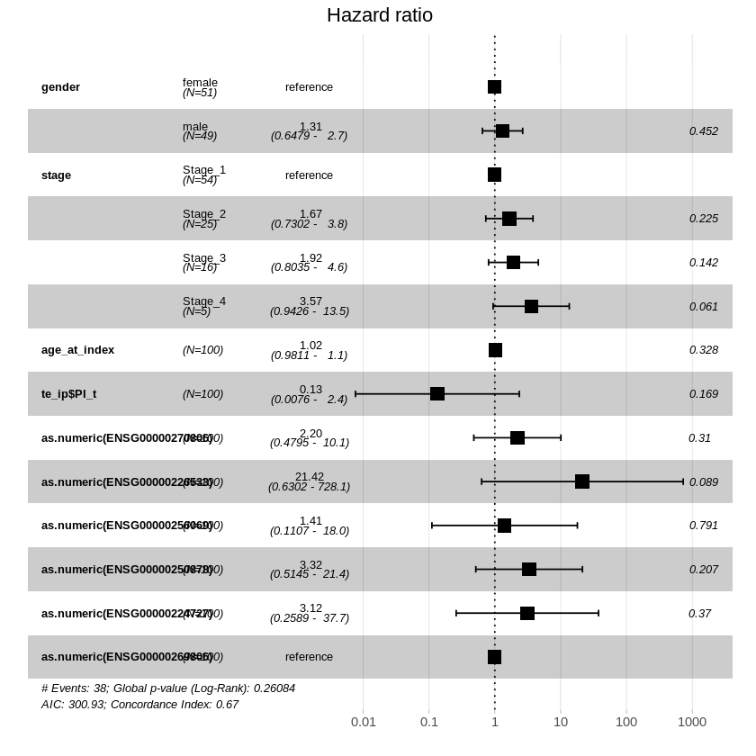

```r
# Fit a Cox proportional hazards model
surv_object_p_t <- Surv(time = te_ip$vital.time, event = te_ip$OS)
fit.coxph_t <- coxph(surv_object_p_t ~   gender + stage + age_at_index + te_ip$PI_t + as.numeric(ENSG00000270806) + as.numeric(ENSG00000226533) + as.numeric(ENSG00000256069) + as.numeric(ENSG00000250878) + as.numeric(ENSG00000224727)+ as.numeric(ENSG00000269806) , data = te_ip )
ggforest(fit.coxph_t, data = te_ip)
```

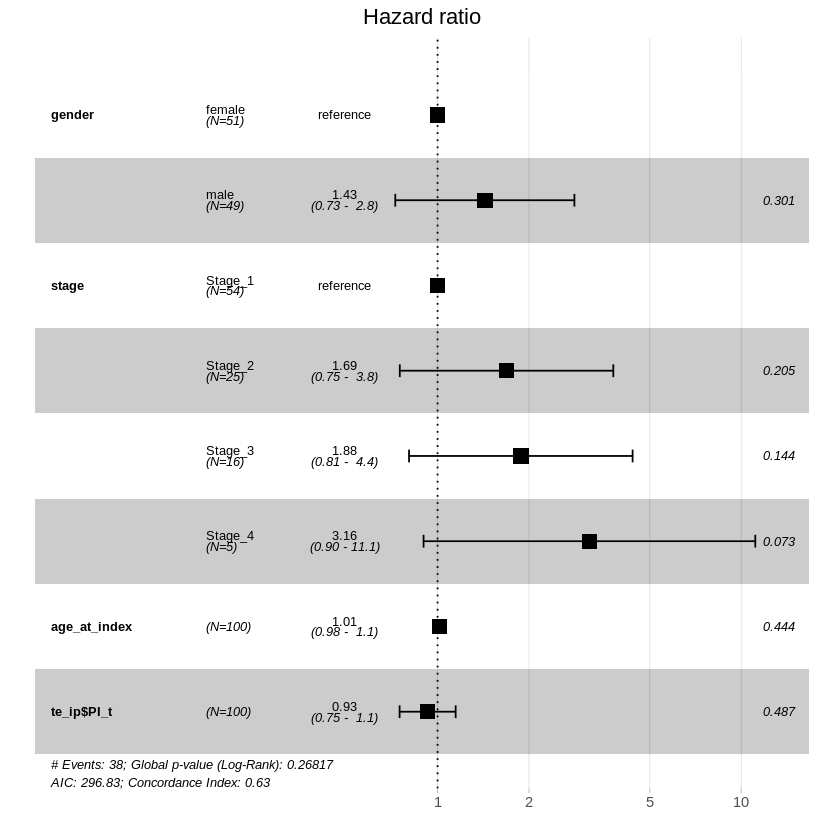

```r
# Multivariate Cox proportional hazards model
surv_object_p_t <- Surv(time = te_ip$vital.time, event = te_ip$OS)
fit.coxph_t <- coxph(surv_object_p_t ~   gender + stage + age_at_index + te_ip$PI_t, data = te_ip )
ggforest(fit.coxph_t, data = te_ip)
```

**Boxplot for test data**

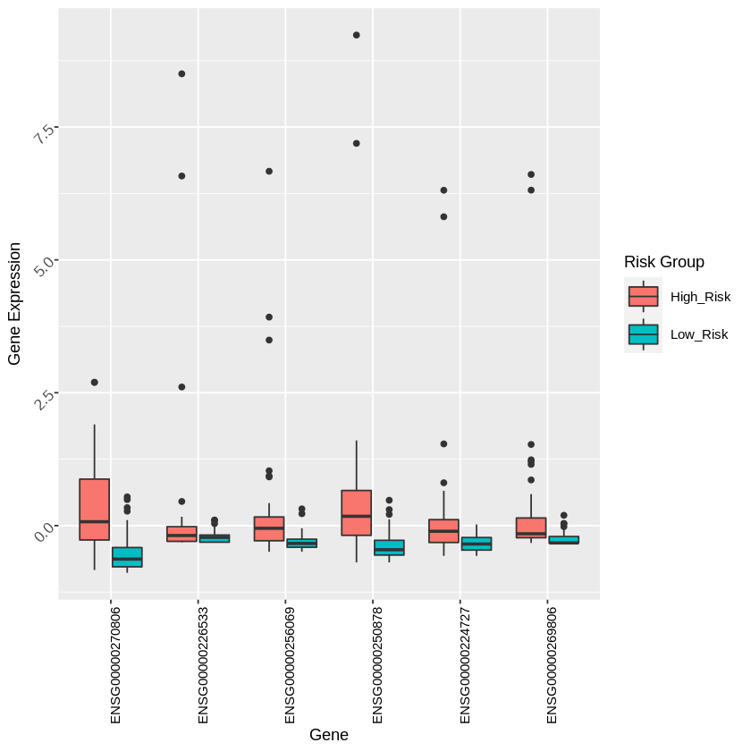

```r
g1t <- as.data.frame(as.numeric(te_ip$ENSG00000270806))
g2t <- as.data.frame(as.numeric(te_ip$ENSG00000226533))
g3t <- as.data.frame(as.numeric(te_ip$ENSG00000256069))
g4t <- as.data.frame(as.numeric(te_ip$ENSG00000250878))
g5t <- as.data.frame(as.numeric(te_ip$ENSG00000224727))
g6t <- as.data.frame(as.numeric(te_ip$ENSG00000269806))


# create a new column risk status based on PI median value
Risk_status_t <- as.data.frame(ifelse(te_ip$PI >= median(as.numeric(te_ip$PI)), "High_Risk", "Low_Risk"))

#combine risk status with gene expression of key genes
new_data_t <- cbind(Risk_status_t, g1t,g2t,g3t,g4t,g5t,g6t)

# add column name
colnames(new_data_t) <- c("Risk", "ENSG00000270806", "ENSG00000226533", "ENSG00000256069", "ENSG00000250878", "ENSG00000224727", "ENSG00000269806")

#melt dataframe
df_m_t<- melt(new_data_t)

#create boxplot
bb <- ggplot(df_m_t, aes(factor(variable), value)) + geom_boxplot(aes(fill = Risk))

#Add axis title, legend title and adjust font size
bb + theme(legend.key.size = unit(0.9, "cm"), legend.text = element_text(color= "Black", size= 9), axis.text.x = element_text(color= "Black", size= 9, angle= 90), axis.text.y = element_text(size= 10, angle= 45)) + xlab("Gene") + ylab("Gene Expression") + labs(fill = "Risk Group")
```

Our model is not validated on test data based on this combination of features.

**Note:** For the final project work purpose, We can try more combination not just these 6 genes to validate model on test data

# 7. Classification Prediction models

**Risk group classification** Here, First Risk_status label will be assigned to the each samples based on the PI model. Thus "High_Risk =1" was assigned to samples PI > median(PI) value and Low_Risk=0 will be assigned to PI < median(PI) value. Next, for this excersie purpose, I am considering only 56 significant genes (based on univariate analysis as start input for Risk group classification. Since, survival analysis indicates stage is important prognostic factor. Thus, I have also considered tumor stage as one of input features.

**Note:** Here, I am creating binary classification models (High risk vs low risk)

## Create training and test data for selected features

```r
#create data frame for features only
top_CI <- as.data.frame(row.names(CI_features))

#add class column as well
#top1<-rbind(c("class"), top1)

#add column names
colnames(top_CI) <- c("ID")

#Write into a file
write.table(top_CI,'top_rf_features_list.txt', row.names=F,  sep='\t', quote=FALSE)
```

Prepare training and test data with selected features

```r
# Prepare training data with only selected top features
input_data_tr1_t <- t(input_data_tr1)
input_data_te1_t <- t(input_data_te1)

#Prepare test data with selected features
tr_selected_data1 <- as.data.frame(input_data_tr1_t[row.names(input_data_tr1_t) %in% c(top_CI$ID), ])

#Prepare test data with selected features
te_selected_data1 <- as.data.frame(input_data_te1_t[row.names(input_data_te1_t) %in% c(top_CI$ID), ])

#Check dimensions of dataset
dim(tr_selected_data1)
dim(te_selected_data1)
```

1. 56

2. 382

1. 56

2. 100

```r
#transpose train and test data
tr1 <-t(tr_selected_data1)
te1 <-t(te_selected_data1)

dim(tr1)
dim(te1)

tr_class <- as.data.frame(ip$stage_n)
te_class <- as.data.frame(te_ip$stage_n )

colnames(tr_class)<- c("T_stage")
colnames(te_class)<- c("T_stage")

dim(tr_class)
dim(te_class)

Risk_tr <- as.data.frame(new_data$Risk)
Risk_te <- as.data.frame(new_data_t$Risk)

colnames(Risk_tr)<- c("Risk")
colnames(Risk_te)<- c("Risk")

dim(Risk_tr)
dim(Risk_te)
```

1. 382

2. 56

1. 100

2. 56

1. 382

2. 1

1. 100

2. 1

1. 382

2. 1

1. 100

2. 1

```r
# combine clinical data with gene expression for selected train & Test data
final_sel_tr_c <- cbind(Risk_tr, tr_class, tr1)
final_sel_te_c <- cbind(Risk_te, te_class, te1)

final_sel_tr_c$Risk_status<- recode(final_sel_tr_c$Risk,"c('High_Risk')=1;c('Low_Risk')=0")
final_sel_te_c$Risk_status <- recode(final_sel_te_c$Risk,"c('High_Risk')=1;c('Low_Risk')=0")


final_sel_tr_c1 <- final_sel_tr_c[2:ncol(final_sel_tr_c)]
final_sel_te_c1 <- final_sel_te_c[2:ncol(final_sel_te_c)]


#Check dimensions
dim(final_sel_tr_c1)
dim(final_sel_te_c1)


head(final_sel_tr_c1,3)
head(final_sel_te_c1,3)

#write into file
write.table(final_sel_tr_c1, file = "final_sel_tr_c1.txt", sep="\t", quote=F, row.names = F)
write.table(final_sel_te_c1, file = "final_sel_te_c1.txt", sep="\t", quote=F, row.names = F)
```

1. 382

2. 58

1. 100

2. 58

A data.frame: 3 × 58

|  | T_stage <dbl> | ENSG00000273797.1 <chr> | ENSG00000269806.1 <chr> | ENSG00000253953.2 <chr> | ENSG00000223653.4 <chr> | ENSG00000259915.2 <chr> | ENSG00000261226.1 <chr> | ENSG00000260249.2 <chr> | ENSG00000279166.1 <chr> | ENSG00000249717.1 <chr> | ⋯ | ENSG00000162669.14 <chr> | ENSG00000230661.1 <chr> | ENSG00000258274.1 <chr> | ENSG00000122432.15 <chr> | ENSG00000265118.4 <chr> | ENSG00000250878.3 <chr> | ENSG00000249899.4 <chr> | ENSG00000277548.1 <chr> | ENSG00000271716.1 <chr> | Risk_status <dbl> |
| --- | --- | --- | --- | --- | --- | --- | --- | --- | --- | --- | --- | --- | --- | --- | --- | --- | --- | --- | --- | --- | --- |
| TCGA-05-4249-01A | 1 | -0.353 | -0.244 | -0.652 | -0.149 | -0.371 | -0.084 | -0.815 | -0.138 | -0.199 | ⋯ | -0.624 | -0.018 | -0.014 | -0.431 | -0.232 | -0.415 | 0.063 | -0.435 | -0.167 | 0 |
| TCGA-05-4382-01A | 1 | -0.192 | -0.326 | 3.319 | -0.280 | -0.286 | -0.309 | -0.572 | -0.169 | -0.221 | ⋯ | 2.099 | -0.235 | -0.154 | -0.292 | -0.330 | -0.359 | -0.179 | -0.428 | -0.198 | 0 |
| TCGA-05-4389-01A | 1 | -0.288 | -0.243 | -0.765 | -0.508 | -0.401 | -0.336 | -0.292 | -0.215 | -0.126 | ⋯ | 0.857 | -0.235 | -0.229 | -0.479 | -0.517 | -0.317 | -0.376 | -0.838 | -0.165 | 0 |

A data.frame: 3 × 58

|  | T_stage <dbl> | ENSG00000273797.1 <chr> | ENSG00000269806.1 <chr> | ENSG00000253953.2 <chr> | ENSG00000223653.4 <chr> | ENSG00000259915.2 <chr> | ENSG00000261226.1 <chr> | ENSG00000260249.2 <chr> | ENSG00000279166.1 <chr> | ENSG00000249717.1 <chr> | ⋯ | ENSG00000162669.14 <chr> | ENSG00000230661.1 <chr> | ENSG00000258274.1 <chr> | ENSG00000122432.15 <chr> | ENSG00000265118.4 <chr> | ENSG00000250878.3 <chr> | ENSG00000249899.4 <chr> | ENSG00000277548.1 <chr> | ENSG00000271716.1 <chr> | Risk_status <dbl> |
| --- | --- | --- | --- | --- | --- | --- | --- | --- | --- | --- | --- | --- | --- | --- | --- | --- | --- | --- | --- | --- | --- |
| TCGA-05-4417-01A | 1 | -0.417 | -0.326 | 0.596 | -0.256 | -0.288 | -0.041 | -0.113 | -0.166 | -0.242 | ⋯ | -0.388 | 0.169 | 0.550 | -0.549 | 0.076 | -0.341 | -0.037 | -0.193 | -0.278 | 0 |
| TCGA-05-4422-01A | 1 | -0.115 | -0.326 | 1.108 | -0.346 | 0.027 | -0.140 | 4.327 | -0.141 | -0.183 | ⋯ | 0.148 | -0.235 | -0.200 | -0.479 | -0.237 | -0.388 | -0.226 | -0.037 | -0.097 | 0 |
| TCGA-35-4122-01A | 1 | -0.265 | -0.326 | -0.034 | -0.197 | -0.279 | -0.401 | -0.858 | -0.215 | -0.242 | ⋯ | 0.365 | -0.235 | 0.340 | -0.552 | -0.246 | -0.470 | -0.376 | -1.326 | -0.278 | 0 |

## RF model

Here, we will develop Random Forest model with `randomForest` package as well as `caret` package

```r
install.packages("randomForest")
```

```r
library("randomForest")
```

Read training and test data for Classification

```r
#Read training data
final_sel_tr_c1  <- read.table("final_sel_tr_c1.txt", sep = "\t", header=TRUE)
#Read training data
final_sel_te_c1  <- read.table("final_sel_te_c1.txt", sep = "\t", header=TRUE)
```

```r
#define number of trees
numtrees <- as.numeric(500)
#new_tr1 <- as.matrix(new_tr)
rforest <- randomForest(as.factor(Risk_status) ~ ., data=final_sel_tr_c1, ntree=numtrees, metric="Accuracy", importance=TRUE)
```

Model

```r
rforest
```

[output not shown]

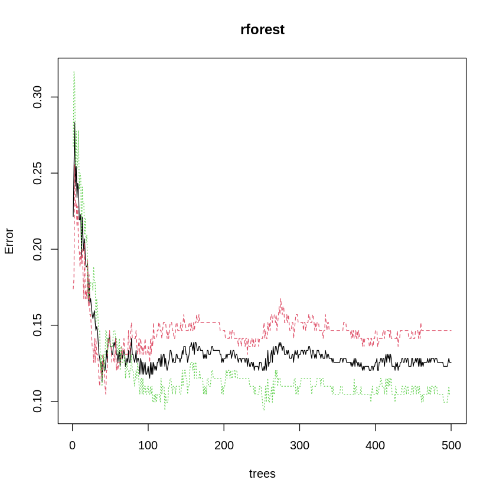

```r
plot(rforest)
```

### Create an output for features by feature importance

A matrix: 6 × 2 of type dbl

|  | MeanDecreaseAccuracy | MeanDecreaseGini |
| --- | --- | --- |
| T_stage | 2.1874037 | 0.5049836 |
| ENSG00000273797.1 | 2.0292900 | 1.6811999 |
| ENSG00000269806.1 | 8.6651566 | 4.4797762 |
| ENSG00000253953.2 | 0.6891555 | 1.6733874 |
| ENSG00000223653.4 | 8.9750097 | 4.9038916 |
| ENSG00000259915.2 | 4.2950597 | 2.3155350 |

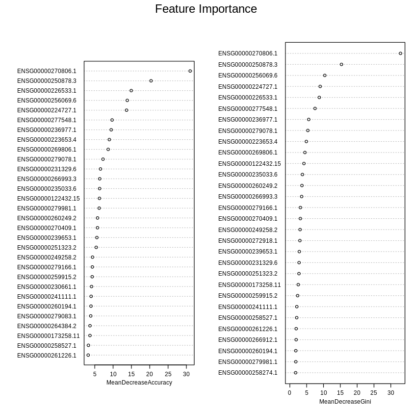

```r
#Feature importance
varImpPlot(rforest, main='Feature Importance', pch=1, cex=0.6)

#Store features in a vaiable as features
rf_features <- varImpPlot(rforest, main='Feature Importance', pch=1, cex=0.6)

head(rf_features)

#Write features in a txt file format
write.table(rf_features,'RF_features_importance.txt', row.names=TRUE,col.names=NA, sep='\t', quote=FALSE)
```

**Sort features based on the MeanDecrease Accuracy (for classification models) or %IncMSE (for regression models)**

```r
# Sort features based on meanDecreaseAccuracy value
sorted_features_rf <- as.data.frame(rf_features[order(rf_features[,"MeanDecreaseAccuracy"], decreasing = TRUE),])
#sorted_features_rf <- as.data.frame(rf_features[order(rf_features[,"%IncMSE"], decreasing = TRUE),])

head(sorted_features_rf)
```

A data.frame: 6 × 2

|  | MeanDecreaseAccuracy <dbl> | MeanDecreaseGini <dbl> |
| --- | --- | --- |
| ENSG00000270806.1 | 31.027577 | 32.884699 |
| ENSG00000250878.3 | 20.355144 | 15.347057 |
| ENSG00000226533.1 | 14.953582 | 8.753131 |
| ENSG00000256069.6 | 13.866291 | 10.383574 |
| ENSG00000224727.1 | 13.672393 | 9.014240 |
| ENSG00000277548.1 | 9.725275 | 7.486375 |

Select top features based on MeandecreaseAccuracy score. Higher mean decrease accuracy score, more important feature would be classification model.

```r
#select only top features (meanDecreaseaccuracy or %IncMSE >1.5)
top_features_rf <- sorted_features_rf[sorted_features_rf$MeanDecreaseAccuracy>1.2, ]
#top_features_rf <- sorted_features_rf[sorted_features_rf[1]>1.5, ]
dim(top_features_rf)
head(top_features_rf)
```

1. 45

2. 2

A data.frame: 6 × 2

|  | MeanDecreaseAccuracy <dbl> | MeanDecreaseGini <dbl> |
| --- | --- | --- |
| ENSG00000270806.1 | 31.027577 | 32.884699 |
| ENSG00000250878.3 | 20.355144 | 15.347057 |
| ENSG00000226533.1 | 14.953582 | 8.753131 |
| ENSG00000256069.6 | 13.866291 | 10.383574 |
| ENSG00000224727.1 | 13.672393 | 9.014240 |
| ENSG00000277548.1 | 9.725275 | 7.486375 |

Install required packages

```r
install.packages("e1071")
```

```r
library(e1071)
```

```r
#Save the model
save(rforest, file = "RF.rda")
```

```r
# Test set
test_set = final_sel_te_c1

#take data with features only
test_set1 <- (test_set[1:57])

head(test_set1)
```

A data.frame: 6 × 57

|  | T_stage <int> | ENSG00000273797.1 <dbl> | ENSG00000269806.1 <dbl> | ENSG00000253953.2 <dbl> | ENSG00000223653.4 <dbl> | ENSG00000259915.2 <dbl> | ENSG00000261226.1 <dbl> | ENSG00000260249.2 <dbl> | ENSG00000279166.1 <dbl> | ENSG00000249717.1 <dbl> | ⋯ | ENSG00000279083.1 <dbl> | ENSG00000162669.14 <dbl> | ENSG00000230661.1 <dbl> | ENSG00000258274.1 <dbl> | ENSG00000122432.15 <dbl> | ENSG00000265118.4 <dbl> | ENSG00000250878.3 <dbl> | ENSG00000249899.4 <dbl> | ENSG00000277548.1 <dbl> | ENSG00000271716.1 <dbl> |
| --- | --- | --- | --- | --- | --- | --- | --- | --- | --- | --- | --- | --- | --- | --- | --- | --- | --- | --- | --- | --- | --- |
| 1 | 1 | -0.417 | -0.326 | 0.596 | -0.256 | -0.288 | -0.041 | -0.113 | -0.166 | -0.242 | ⋯ | -0.069 | -0.388 | 0.169 | 0.550 | -0.549 | 0.076 | -0.341 | -0.037 | -0.193 | -0.278 |
| 2 | 1 | -0.115 | -0.326 | 1.108 | -0.346 | 0.027 | -0.140 | 4.327 | -0.141 | -0.183 | ⋯ | -0.025 | 0.148 | -0.235 | -0.200 | -0.479 | -0.237 | -0.388 | -0.226 | -0.037 | -0.097 |
| 3 | 1 | -0.265 | -0.326 | -0.034 | -0.197 | -0.279 | -0.401 | -0.858 | -0.215 | -0.242 | ⋯ | -0.224 | 0.365 | -0.235 | 0.340 | -0.552 | -0.246 | -0.470 | -0.376 | -1.326 | -0.278 |
| 4 | 1 | -0.331 | -0.326 | -0.721 | -0.509 | -0.401 | -0.229 | -0.844 | -0.206 | -0.242 | ⋯ | -0.196 | -0.264 | -0.161 | -0.165 | -0.003 | -0.158 | -0.381 | -0.313 | -0.871 | -0.203 |
| 5 | 1 | -0.417 | -0.326 | -0.240 | -0.160 | -0.326 | -0.401 | -0.762 | -0.186 | -0.242 | ⋯ | -0.224 | -0.652 | 0.007 | -0.315 | -0.165 | -0.428 | -0.692 | -0.376 | -1.326 | -0.278 |
| 6 | 1 | -0.173 | -0.017 | -0.624 | -0.246 | -0.165 | 0.330 | -0.258 | -0.090 | -0.130 | ⋯ | -0.224 | -0.091 | -0.022 | 0.057 | -0.370 | 0.473 | 0.196 | -0.027 | -0.605 | -0.278 |

```r
#Prediction on test data
predictions_RF <- predict(rforest, test_set1)
```

```r
#Create confusion matrix
RF_cm_matrix <- confusionMatrix(as.factor(predictions_RF), as.factor(test_set$Risk_status))
RF_cm_matrix
```

```
Confusion Matrix and Statistics

          Reference
Prediction  0  1
         0 46  8
         1  4 42

               Accuracy : 0.88
                 95% CI : (0.7998, 0.9364)
    No Information Rate : 0.5
    P-Value [Acc > NIR] : 9.557e-16

                  Kappa : 0.76

 Mcnemar's Test P-Value : 0.3865

            Sensitivity : 0.9200
            Specificity : 0.8400
         Pos Pred Value : 0.8519
         Neg Pred Value : 0.9130
             Prevalence : 0.5000
         Detection Rate : 0.4600
   Detection Prevalence : 0.5400
      Balanced Accuracy : 0.8800

       'Positive' Class : 0
```

```r
#overall accuracy of the model on test data
acc <- as.data.frame(RF_cm_matrix$overall)
acc

#Results on test data
res <- as.data.frame(RF_cm_matrix$byClass)
res

#write test data into a file
write.table(res, file = "Results_test_set.txt", sep="\t", quote=F, row.names = F)
```

A data.frame: 7 × 1

|  | RF_cm_matrix$overall <dbl> |
| --- | --- |
| Accuracy | 8.800000e-01 |
| Kappa | 7.600000e-01 |
| AccuracyLower | 7.997643e-01 |
| AccuracyUpper | 9.364311e-01 |
| AccuracyNull | 5.000000e-01 |
| AccuracyPValue | 9.556788e-16 |
| McnemarPValue | 3.864762e-01 |

A data.frame: 11 × 1

|  | RF_cm_matrix$byClass <dbl> |
| --- | --- |
| Sensitivity | 0.9200000 |
| Specificity | 0.8400000 |
| Pos Pred Value | 0.8518519 |
| Neg Pred Value | 0.9130435 |
| Precision | 0.8518519 |
| Recall | 0.9200000 |
| F1 | 0.8846154 |
| Prevalence | 0.5000000 |
| Detection Rate | 0.4600000 |
| Detection Prevalence | 0.5400000 |
| Balanced Accuracy | 0.8800000 |

RF with cross validation (3 fold)

```r
#Create Cross validation (CV) object
train_control <- trainControl(method="repeatedcv", number=3)
```

```r
#RF with CV
RF_cv <- train(as.factor(Risk_status) ~., method = "rf", trControl = train_control,  data=final_sel_tr_c1)
```

```r
RF_cv
```

```
Random Forest

382 samples
 57 predictor
  2 classes: '0', '1'

No pre-processing
Resampling: Cross-Validated (3 fold, repeated 1 times)
Summary of sample sizes: 254, 256, 254
Resampling results across tuning parameters:

  mtry  Accuracy   Kappa
   2    0.8246528  0.6493056
  29    0.9031085  0.8062169
  57    0.8979001  0.7958003

Accuracy was used to select the optimal model using the largest value.
The final value used for the model was mtry = 29.
```

```r
#Save the model
save(RF_cv, file = "RF_cv.rda")
```

```r
#Prediction on train data
predictions_RF_cv_tr<- predict(RF_cv, final_sel_tr_c1[1:57])
```

```r
#Create confusion matrix
RF_cm_matrix_cv_tr <- confusionMatrix(as.factor(predictions_RF_cv_tr), as.factor(final_sel_tr_c1$Risk_status))
RF_cm_matrix_cv_tr
```

```
Confusion Matrix and Statistics

          Reference
Prediction   0   1
         0 191   0
         1   0 191

               Accuracy : 1
                 95% CI : (0.9904, 1)
    No Information Rate : 0.5
    P-Value [Acc > NIR] : < 2.2e-16

                  Kappa : 1

 Mcnemar's Test P-Value : NA

            Sensitivity : 1.0
            Specificity : 1.0
         Pos Pred Value : 1.0
         Neg Pred Value : 1.0
             Prevalence : 0.5
         Detection Rate : 0.5
   Detection Prevalence : 0.5
      Balanced Accuracy : 1.0

       'Positive' Class : 0
```

```r
#Prediction on test data
predictions_RF_cv_te <- predict(RF_cv, test_set1)
```

```r
#Create confusion matrix of test data
RF_cm_matrix_cv_te <- confusionMatrix(as.factor(predictions_RF_cv_te), as.factor(test_set$Risk_status))
RF_cm_matrix_cv_te
```

```
Confusion Matrix and Statistics

          Reference
Prediction  0  1
         0 47 10
         1  3 40

               Accuracy : 0.87
                 95% CI : (0.788, 0.9289)
    No Information Rate : 0.5
    P-Value [Acc > NIR] : 6.565e-15

                  Kappa : 0.74

 Mcnemar's Test P-Value : 0.09609

            Sensitivity : 0.9400
            Specificity : 0.8000
         Pos Pred Value : 0.8246
         Neg Pred Value : 0.9302
             Prevalence : 0.5000
         Detection Rate : 0.4700
   Detection Prevalence : 0.5700
      Balanced Accuracy : 0.8700

       'Positive' Class : 0
```

## Develop Logistic Regression model

Create Logistic Regression model with `glm` function on training data. With cv.glm we will perform cross validation on training data. Here, we are directly developing 3 fold cross validation prediction model

```r
#Fit LR model
LR_model_cv <- train(factor(Risk_status) ~ ., data = final_sel_tr_c1, method = 'glm', metric = 'Accuracy', trControl = train_control)
```

```r
#Prediction on training data
predictions_LR_tr<- predict(LR_model_cv, final_sel_tr_c1[1:57])
```

```r
#Confusion matrix
LR_cm_matrix_tr <- confusionMatrix(as.factor(predictions_LR_tr ), as.factor(final_sel_tr_c1$Risk_status))
LR_cm_matrix_tr
```

```
Confusion Matrix and Statistics

          Reference
Prediction   0   1
         0 191   0
         1   0 191

               Accuracy : 1
                 95% CI : (0.9904, 1)
    No Information Rate : 0.5
    P-Value [Acc > NIR] : < 2.2e-16

                  Kappa : 1

 Mcnemar's Test P-Value : NA

            Sensitivity : 1.0
            Specificity : 1.0
         Pos Pred Value : 1.0
         Neg Pred Value : 1.0
             Prevalence : 0.5
         Detection Rate : 0.5
   Detection Prevalence : 0.5
      Balanced Accuracy : 1.0

       'Positive' Class : 0
```

```r
#Prediction on test data
predictions_LR<- predict(LR_model_cv, test_set1)
```

```r
#Confusion matrix
LR_cm_matrix <- confusionMatrix(as.factor(predictions_LR ), as.factor(test_set$Risk_status))
LR_cm_matrix
```

```
Confusion Matrix and Statistics

          Reference
Prediction  0  1
         0 48  8
         1  2 42

               Accuracy : 0.9
                 95% CI : (0.8238, 0.951)
    No Information Rate : 0.5
    P-Value [Acc > NIR] : <2e-16

                  Kappa : 0.8

 Mcnemar's Test P-Value : 0.1138

            Sensitivity : 0.9600
            Specificity : 0.8400
         Pos Pred Value : 0.8571
         Neg Pred Value : 0.9545
             Prevalence : 0.5000
         Detection Rate : 0.4800
   Detection Prevalence : 0.5600
      Balanced Accuracy : 0.9000

       'Positive' Class : 0
```

```r
#overall accuracy of the model on test data
LR_acc <- as.data.frame(LR_cm_matrix$overall)
LR_acc

#Results on test data
LR_res <- as.data.frame(LR_cm_matrix$byClass)
LR_res
#write test data into a file
write.table(res, file = "LR_Results_test_set.txt", sep="\t", quote=F, row.names = F)
```

A data.frame: 7 × 1

|  | LR_cm_matrix$overall <dbl> |
| --- | --- |
| Accuracy | 9.000000e-01 |
| Kappa | 8.000000e-01 |
| AccuracyLower | 8.237774e-01 |
| AccuracyUpper | 9.509953e-01 |
| AccuracyNull | 5.000000e-01 |
| AccuracyPValue | 1.531645e-17 |
| McnemarPValue | 1.138463e-01 |

A data.frame: 11 × 1

|  | LR_cm_matrix$byClass <dbl> |
| --- | --- |
| Sensitivity | 0.9600000 |
| Specificity | 0.8400000 |
| Pos Pred Value | 0.8571429 |
| Neg Pred Value | 0.9545455 |
| Precision | 0.8571429 |
| Recall | 0.9600000 |
| F1 | 0.9056604 |
| Prevalence | 0.5000000 |
| Detection Rate | 0.4800000 |
| Detection Prevalence | 0.5600000 |
| Balanced Accuracy | 0.9000000 |

## SVM models

SVM radial & SVM linear Models

```r
install.packages("kernlab")
```

```r
library(kernlab)
```

```r
# Fit SVM RBF model
svm_RBF <- train(factor(Risk_status) ~ ., data = as.matrix(final_sel_tr_c1), method = 'svmRadial', metric = 'Accuracy', trControl = train_control)
```

```r
svm_RBF
```

```
Support Vector Machines with Radial Basis Function Kernel

382 samples
 57 predictor
  2 classes: '0', '1'

No pre-processing
Resampling: Cross-Validated (3 fold, repeated 1 times)
Summary of sample sizes: 255, 255, 254
Resampling results across tuning parameters:

  C     Accuracy   Kappa
  0.25  0.7800197  0.5600432
  0.50  0.8350353  0.6700849
  1.00  0.8663673  0.7327502

Tuning parameter 'sigma' was held constant at a value of 0.01788908
Accuracy was used to select the optimal model using the largest value.
The final values used for the model were sigma = 0.01788908 and C = 1.
```

```r
#Prediction on train data
predictions_SVC_RBF1 <- predict(svm_RBF, final_sel_tr_c1[1:57])
```

```r
#Prediction on test data
predictions_SVC_RBF_t <- predict(svm_RBF, test_set1)
```

```r
#Create confusion matrix
SVM_RF_cm_matrix <- confusionMatrix(as.factor(predictions_SVC_RBF_t), as.factor(test_set$Risk_status))
SVM_RF_cm_matrix
```

```
Confusion Matrix and Statistics

          Reference
Prediction  0  1
         0 47 13
         1  3 37

               Accuracy : 0.84
                 95% CI : (0.7532, 0.9057)
    No Information Rate : 0.5
    P-Value [Acc > NIR] : 1.303e-12

                  Kappa : 0.68

 Mcnemar's Test P-Value : 0.02445

            Sensitivity : 0.9400
            Specificity : 0.7400
         Pos Pred Value : 0.7833
         Neg Pred Value : 0.9250
             Prevalence : 0.5000
         Detection Rate : 0.4700
   Detection Prevalence : 0.6000
      Balanced Accuracy : 0.8400

       'Positive' Class : 0
```

**SVM -Linear model (SVM with Linear Kernal)**

```r
# Deevelop SVM linear model
svm_linear <- train(as.factor(Risk_status) ~., method = "svmLinear", trControl = train_control,  data=final_sel_tr_c1)
```

```r
svm_linear
```

```
Support Vector Machines with Linear Kernel

382 samples
 57 predictor
  2 classes: '0', '1'

No pre-processing
Resampling: Cross-Validated (3 fold, repeated 1 times)
Summary of sample sizes: 254, 255, 255
Resampling results:

  Accuracy   Kappa
  0.9135089  0.8270005

Tuning parameter 'C' was held constant at a value of 1
```

```r
#Prediction on train data
predictions_svm_l <- predict(svm_linear, final_sel_tr_c1[1:57])
```

```r
#confusion matrix
SVM_Linear_cm_matrix_tr <- confusionMatrix(as.factor(predictions_svm_l), as.factor(final_sel_tr_c1$Risk_status))
SVM_Linear_cm_matrix_tr
```

```
Confusion Matrix and Statistics

          Reference
Prediction   0   1
         0 190   0
         1   1 191

               Accuracy : 0.9974
                 95% CI : (0.9855, 0.9999)
    No Information Rate : 0.5
    P-Value [Acc > NIR] : <2e-16

                  Kappa : 0.9948

 Mcnemar's Test P-Value : 1

            Sensitivity : 0.9948
            Specificity : 1.0000
         Pos Pred Value : 1.0000
         Neg Pred Value : 0.9948
             Prevalence : 0.5000
         Detection Rate : 0.4974
   Detection Prevalence : 0.4974
      Balanced Accuracy : 0.9974

       'Positive' Class : 0
```

```r
#Prediction on test data
predictions_svm_l_t <- predict(svm_linear, test_set1)
```

```r
#confusion matrix
SVM_Linear_cm_matrix <- confusionMatrix(as.factor(predictions_svm_l_t  ), as.factor(test_set$Risk_status))
SVM_Linear_cm_matrix
```

```
Confusion Matrix and Statistics

          Reference
Prediction  0  1
         0 50  7
         1  0 43

               Accuracy : 0.93
                 95% CI : (0.8611, 0.9714)
    No Information Rate : 0.5
    P-Value [Acc > NIR] : < 2e-16

                  Kappa : 0.86

 Mcnemar's Test P-Value : 0.02334

            Sensitivity : 1.0000
            Specificity : 0.8600
         Pos Pred Value : 0.8772
         Neg Pred Value : 1.0000
             Prevalence : 0.5000
         Detection Rate : 0.5000
   Detection Prevalence : 0.5700
      Balanced Accuracy : 0.9300

       'Positive' Class : 0
```

# 7. Conclusion

**Prognostic Analysis**

First, I have identified 594 significant differentially expressed genes between cancer & normal samples. These selected genes were further used for downstream analyses. Based on univariate survival analysis of on TCGA-LUAD data, I have identified 56 significant (p-value <0.05) molecular (transcriptomics) signatures. Subsequently, 23 significant bad prognostic signatures were filetered out (HR >1.2 and p-value <0.05). Further Prognostic Index (PI) model was developed using top 6 genes. Besides, tumor stage observed to be the most significant prognostic signature. Eventually, multivariate survival analysis was performed to understand independent prognostic potential of these clinical & molecular signatures.

Although, these models are not significantly performed on validation data with this set of signatures. Performance of these models can be improved by applying different combination of features for publication purpose.

**Classification Prediction Model**

Next, Risk status labels (High Risk = 1 and Low Risk =0) were assigned to the samples in traing and test based on 6 genes based PI models.

What need to be done next to improve the performance of Risk groups prognostic prediction model for publication or project purpose:

1. Need more PI models (based on different combination of features) which can also be validated on test dataset, especially for the assignment of High-risk and low risk group
2. Take all genes as input features
3. Next, different feature selection methods need to be implemented, e.g. Recursive feature selection (RFE) by SVM or RF, DGE analysis between High Risk & low risk groups
4. Since stage is observed to be key prognostic siganture. Thus, we can also try to identify genes that can classify early and late stage tumor samples.
5. Need validation on external data to make sure models are not overfitting on TCGA data